# minor_project

$\huge1.INTRODUCTION $.

In this project, we will explore the "nhanes_adult_male_bmx_2020(in)" and "nhanes_adult_female_bmx_2020 2(in)" datasets, which contain body measurement data for adult males and females. The `male dataset` consists of **4099** instances with **7** attributes, while the `female dataset` of **4239** instances with **7** attributes.In this study,I will perform Exploratory Data Analysis (EDA) and test different regression algorithms to `predict the female dataset` based on other information. Then I will discuss the results and see which algorithm works best. Additionally, I will visualize the data to better understand the relationships between the variables.

1. **INTRODUCTION**
2. **USED LIBRARIES**
3. **DATA EXPLORATION**

   **3.1. Detailed Information of the Dataset**

   **3.2. Exploratory Data Analysis**

   **3.3. Explore problems within variables**

   **3.4. Various Visualizations from Dataset**
4. **DATA PREPARATION AND CLEANING**

   **4.1. standarization of Data**

   **4.2. Correction of Column(Attribute) Names**

   **4.3. Discover patterns and relationships**

   **4.4. Split Data and Target**

   **4.4. Preparation of Test and Train Data**

   **4.5. Hypothesis Testing**

   **4.6. Visualizations from FEMALEBMI(target variable)**
5. **BUILDING MODELS**

   **5.1. Multiple Linear Regression**

   **5.2. Polynomial Regression**

   **5.3. Model Selection**
6. **EVALUATING MODELS**

   **6.1. Evaluating Multiple Linear Regression Model**
7. **EXPLORATION OF RESULTS**
8. **CONCLUSION**

## 2.Importing LIBRARIES

```python
import pandas as pd
import numpy as np
import matplotlib.pyplot as plt
from sklearn.model_selection import train_test_split
from sklearn.linear_model import LinearRegression
from scipy.stats import pearsonr, spearmanr
import seaborn as sns
from sklearn.preprocessing import StandardScaler
```

## 3. DATA EXPLORATION

In this section, various explanations will be made about dataset.

### 3.1. Detailed Information of the Dataset

Here I will import the dataset first. Then, I will explain the columns(features) of the dataset one by one.

Import dataset #Read csv file in both male_data and female_data and load into 'data variable'

```python
import pandas as pd
male_data=pd.read_csv("nhanes_adult_male_bmx_2020(in).csv")
female_data=pd.read_csv("nhanes_adult_female_bmx_2020 2(in).csv")
```

### 3.2. Exploratory Data Analysis

Now , i will explore the data both male and female to gain insights about the data.

```python
import pandas as pd
male_data=pd.read_csv("nhanes_adult_male_bmx_2020(in).csv")
male_data.shape   # view dimensions of dataset
```

```
(4099, 7)
```

We can see that there are **(4099)** instances and **(7)** attributes in the data set.

```python
import pandas as pd
female_data=pd.read_csv("nhanes_adult_female_bmx_2020 2(in).csv")
female_data.shape   # view dimensions of dataset
```

```
(4239, 7)
```

We can see that there are **(4239)** instances and **(7)** attributes in the data set.

### View top 10 rows of male_dataset

```python
import pandas as pd
male_data=pd.read_csv("nhanes_adult_male_bmx_2020(in).csv")
male_data.head(10)
```

|  | BMXWT | BMXHT | BMXARML | BMXLEG | BMXARMC | BMXHIP | BMXWAIST |
| --- | --- | --- | --- | --- | --- | --- | --- |
| 0 | 98.8 | 182.3 | 42.0 | 40.1 | 38.2 | 108.2 | 120.4 |
| 1 | 74.3 | 184.2 | 41.1 | 41.0 | 30.2 | 94.5 | 86.8 |
| 2 | 103.7 | 185.3 | 47.0 | 44.0 | 32.0 | 107.8 | 109.6 |
| 3 | 86.0 | 167.8 | 39.5 | 38.4 | 29.0 | 106.4 | 108.3 |
| 4 | 99.4 | 181.6 | 40.4 | 39.9 | 36.0 | 120.2 | 107.0 |
| 5 | 90.2 | 162.5 | 38.7 | 38.0 | 37.3 | 110.2 | 116.2 |
| 6 | 45.5 | 159.3 | 36.2 | 38.0 | 24.4 | 82.0 | 67.2 |
| 7 | 64.0 | 174.9 | 37.0 | 45.0 | 29.2 | 88.9 | 82.5 |
| 8 | 67.9 | 166.2 | 37.3 | 40.3 | 31.0 | 93.4 | 87.0 |
| 9 | 75.2 | 172.6 | 38.6 | 41.5 | 32.0 | 96.4 | 95.0 |

## View top 10 rows of female_dataset

```python
import pandas as pd
female_data=pd.read_csv("nhanes_adult_female_bmx_2020 2(in).csv")
female_data.head(10)
```

|  | BMXWT | BMXHT | BMXARML | BMXLEG | BMXARMC | BMXHIP | BMXWAIST |
| --- | --- | --- | --- | --- | --- | --- | --- |
| 0 | 97.1 | 160.2 | 34.7 | 40.8 | 35.8 | 126.1 | 117.9 |
| 1 | 91.1 | 152.7 | 33.5 | 33.0 | 38.5 | 125.5 | 103.1 |
| 2 | 73.0 | 161.2 | 37.4 | 38.0 | 31.8 | 106.2 | 92.0 |
| 3 | 61.7 | 157.4 | 38.0 | 34.7 | 29.0 | 101.0 | 90.5 |
| 4 | 55.4 | 154.6 | 34.6 | 34.0 | 28.3 | 92.5 | 73.2 |
| 5 | 62.0 | 144.7 | 32.5 | 34.2 | 29.8 | 106.7 | 84.8 |
| 6 | 66.2 | 166.5 | 37.5 | 37.6 | 32.0 | 96.3 | 95.7 |
| 7 | 75.9 | 154.5 | 35.4 | 37.6 | 32.7 | 107.7 | 98.7 |
| 8 | 77.2 | 159.2 | 38.5 | 40.5 | 35.7 | 102.0 | 97.5 |
| 9 | 91.6 | 174.5 | 36.1 | 45.9 | 35.2 | 121.3 | 100.3 |

## View summary of dataset for both male and female

```python
male_data.info()   ### View summary of dataset

female_data.info()  ### View summary of dataset
```

```
<class 'pandas.core.frame.DataFrame'>
RangeIndex: 4099 entries, 0 to 4098
Data columns (total 7 columns):
 #   Column    Non-Null Count  Dtype
---  ------    --------------  -----
 0   BMXWT     4099 non-null   float64
 1   BMXHT     4099 non-null   float64
 2   BMXARML   4099 non-null   float64
 3   BMXLEG    4099 non-null   float64
 4   BMXARMC   4099 non-null   float64
 5   BMXHIP    4099 non-null   float64
 6   BMXWAIST  4099 non-null   float64
dtypes: float64(7)
memory usage: 224.3 KB
<class 'pandas.core.frame.DataFrame'>
RangeIndex: 4239 entries, 0 to 4238
Data columns (total 7 columns):
 #   Column    Non-Null Count  Dtype
---  ------    --------------  -----
 0   BMXWT     4239 non-null   float64
 1   BMXHT     4239 non-null   float64
 2   BMXARML   4239 non-null   float64
 3   BMXLEG    4239 non-null   float64
 4   BMXARMC   4239 non-null   float64
 5   BMXHIP    4239 non-null   float64
 6   BMXWAIST  4239 non-null   float64
dtypes: float64(7)
memory usage: 231.9 KB
```

## Check data types of columns of dataframe in both male and female dataset

```python
import pandas as pd
male_data=pd.read_csv("nhanes_adult_male_bmx_2020(in).csv")
male_data.dtypes   ### Check data types of columns of dataframe
```

```
BMXWT       float64
BMXHT       float64
BMXARML     float64
BMXLEG      float64
BMXARMC     float64
BMXHIP      float64
BMXWAIST    float64
dtype: object
```

```python
import pandas as pd
female_data=pd.read_csv("nhanes_adult_female_bmx_2020 2(in).csv")
female_data.dtypes   ### Check data types of columns of dataframe
```

```
BMXWT       float64
BMXHT       float64
BMXARML     float64
BMXLEG      float64
BMXARMC     float64
BMXHIP      float64
BMXWAIST    float64
dtype: object
```

Now, we can see that all the columns of the dataframe are of type numeric.

Summary of variables:

**-->** There are `7 numerical variables` in the dataset.

**-->** All of the variables are of `continuous type`.

## 3.3. Explore problems within variables

Now, I will explore problems within variables. Missing values in variables.

```python
import pandas as pd
male_data=pd.read_csv("nhanes_adult_male_bmx_2020(in).csv")
male_data_df=pd.DataFrame(male_data)
male_data_df.isnull().sum()
```

```
BMXWT       0
BMXHT       0
BMXARML     0
BMXLEG      0
BMXARMC     0
BMXHIP      0
BMXWAIST    0
dtype: int64
```

```python
import pandas as pd
female_data=pd.read_csv("nhanes_adult_female_bmx_2020 2(in).csv")
female_data_df=pd.DataFrame(female_data)
female_data_df.isnull().sum()
```

```
BMXWT       0
BMXHT       0
BMXARML     0
BMXLEG      0
BMXARMC     0
BMXHIP      0
BMXWAIST    0
dtype: int64
```

Now ,we can see our dataset have `no missing value(NaN)`.

## Let's see the various statistics about the numeric data.

```python
import pandas as pd
# view summary statistics in numerical variables
male_data=pd.read_csv("nhanes_adult_male_bmx_2020(in).csv")
male_data_df=pd.DataFrame(male_data)
#print(male_data_df.describe(),1)
print(round(male_data_df.describe(),1))
```

```
        BMXWT   BMXHT  BMXARML  BMXLEG  BMXARMC  BMXHIP  BMXWAIST
count  4099.0  4099.0   4099.0  4099.0   4099.0  4099.0    4099.0
mean     88.4   173.8     39.2    41.3     34.3   104.5     101.8
std      21.4     7.7      2.4     3.2      4.8    12.2      16.6
min      36.8   144.6     29.6    27.5     19.0    77.0      62.3
25%      73.3   168.6     37.6    39.2     31.0    96.0      90.1
50%      85.0   173.8     39.1    41.2     34.0   102.7     100.5
75%      99.8   178.9     40.9    43.5     37.3   110.6     112.0
max     204.6   199.6     49.9    53.0     53.6   174.9     170.8
```

```python
# view summary statistics in numerical variables
import pandas as pd
# view summary statistics in numerical variables
female_data=pd.read_csv("nhanes_adult_female_bmx_2020 2(in).csv")
female_data_df=pd.DataFrame(female_data)
print(round(female_data_df.describe(),1))
```

```
        BMXWT   BMXHT  BMXARML  BMXLEG  BMXARMC  BMXHIP  BMXWAIST
count  4239.0  4239.0   4239.0  4239.0   4239.0  4239.0    4239.0
mean     77.4   160.1     36.0    37.2     32.7   109.2      98.5
std      21.5     7.1      2.3     3.2      5.6    15.6      17.4
min      32.6   131.1     28.5    25.0     17.9    74.0      56.4
25%      61.6   155.3     34.4    35.0     28.7    97.7      86.0
50%      73.6   160.1     36.0    37.1     32.1   106.7      97.1
75%      88.7   164.8     37.5    39.3     36.1   117.9     109.4
max     180.9   189.3     46.7    49.1     57.2   179.0     178.0
```

Next , `DataFrame` change into numpy matrices named **'male'** and **'female'**, each with **7** columns: `weight, height, upper arm length, upper leg length, arm circumference, hip circumference, and waist circumference`.

```python
import numpy as np
# Load the data from the CSV files into numpy matrices
male = np.genfromtxt('nhanes_adult_male_bmx_2020(in).csv', delimiter=',')
female = np.genfromtxt('nhanes_adult_female_bmx_2020 2(in).csv', delimiter=',')

# Check the shape of the matrices
print(male.shape)  # Should print (num_rows, 7)
print(female.shape)  # Should print (num_rows, 7)
```

```
(4100, 7)
(4240, 7)
```

**Two datasets** is successfully converted into numpy matrices.

## 3.4. Various Visualizations from Dataset

Now, we have a basic understanding of our data. I will supplement it with some data visualization to get better understanding of our data.

Plot **histograms** of `female and male weights` I'll create a single plot with `two subfigures` using matplotlib.pyplot.subplot. The `top subfigure` will show the histogram of **female weights**, and the `bottom subfigure` will show the histogram of **male weights**. I'll set the `x-axis limits` to be identical for both subfigures. Check the distribution of variables. Now, I will plot the histograms to check variable distributions to find out if they are `normal` or `skewed`.

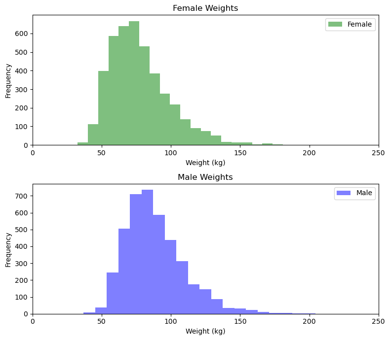

```python
import matplotlib.pyplot as plt
import pandas as pd

male_data = pd.read_csv("nhanes_adult_male_bmx_2020(in).csv")
female_data = pd.read_csv("nhanes_adult_female_bmx_2020 2(in).csv")

# Create a figure with two subplots
fig, axs = plt.subplots(2, 1, figsize=(8, 7))

# Plot the histogram of female weights on the top subplot
#axs[0].hist(female_data.iloc[:, 0], bins=20)
axs[0].hist(female_data.iloc[:, 0], bins=20, color='green', alpha=0.5, label='Female') # Assuming weight is the first column
axs[0].set_title('Female Weights')
axs[0].set_xlabel('Weight (kg)')
axs[0].set_ylabel('Frequency')
axs[0].legend()

# Plot the histogram of male weights on the bottom subplot
#axs[1].hist(male_data.iloc[:, 0], bins=20)  # Assuming weight is the first column
axs[1].hist(male_data.iloc[:, 0], bins=20, color='blue', alpha=0.5, label='Male')
axs[1].set_title('Male Weights')
axs[1].set_xlabel('Weight (kg)')
axs[1].set_ylabel('Frequency')
axs[1].legend()

# Set the x-axis limits to be identical for both subfigures
axs[0].set_xlim([0, 250])  # Adjust the limits as needed
axs[1].set_xlim([0, 250])

# Show the plot
plt.tight_layout()
plt.show()
```

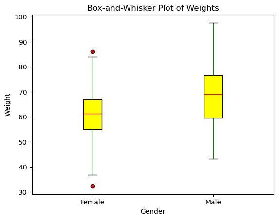

```python
import warnings
import matplotlib.pyplot as plt
import numpy as np
import pandas as pd

# Ignore MatplotlibDeprecationWarning
warnings.filterwarnings("ignore", category=DeprecationWarning)

# Read CSV files
male_data = pd.read_csv("nhanes_adult_male_bmx_2020(in).csv")
female_data = pd.read_csv("nhanes_adult_female_bmx_2020 2(in).csv")

# Assuming you have the female and male weights in two separate arrays
female_weights = np.random.normal(60, 10, 100)
male_weights = np.random.normal(70, 12, 100)

# Assign the arrays to female_data and male_data
female_data = female_weights
male_data = male_weights

# Create a figure and axis
fig, ax = plt.subplots()

# Create a box-and-whisker plot with two boxes side by side
ax.boxplot([female_data, male_data], labels=['Female', 'Male'], boxprops=dict(facecolor='yellow', color='black'), flierprops=dict(markerfacecolor='red', markersize=6), medianprops=dict(color='red'), whiskerprops=dict(color='green'), patch_artist=True)

# Set title and labels
ax.set_title('Box-and-Whisker Plot of Weights')
ax.set_xlabel('Gender')
ax.set_ylabel('Weight')

# Show the plot
#plt.title("Weight Distribution")
plt.show()
```

## Compute numerical aggregates and compare distributions

I'll compute basic numerical aggregates `(measures of location, dispersion, and shape)` for **male** and**female** weights of the two distributions.

```python
import numpy as np
import pandas as pd
import scipy.stats as stats
#Male Weight to perform Aggregation functions
male_data=pd.read_csv("nhanes_adult_male_bmx_2020(in).csv")
male_data = male_data.to_numpy()
male_data_agg = np.array([np.mean(male_data[:, 0]), np.median(male_data[:, 0]), np.std(male_data[:, 0]), stats.skew(male_data[:, 0])])

#Female Weight to perform Aggregation functions
female_data=pd.read_csv("nhanes_adult_female_bmx_2020 2(in).csv")
female_data = female_data.to_numpy()
female_data_agg = np.array([np.mean(female_data[:, 0]), np.median(female_data[:, 0]), np.std(female_data[:, 0]),stats.skew(female_data[:,0])])
print("1.)Male Weight Aggregates:")
print("Mean:", male_data_agg[0])
print("Median:", male_data_agg[1])
print("Standard Deviation:", male_data_agg[2])
print("Skewness:", male_data_agg[3])
print("2.)Female Weight Aggregates:")
print("Mean:", female_data_agg[0])
print("Median:", female_data_agg[1])
print("Standard Deviation:", female_data_agg[2])
print("Skewness:", female_data_agg[3])

# Compare the distributions
print("3.)Comparison:")
print("The mean weight of (males) is", male_data_agg[0], "kg, while the mean weight of (females) is", female_data_agg[0], "kg.")
print("The median weight of (males) is", male_data_agg[1], "kg, while the median weight of (females) is", female_data_agg[1], "kg.")
print("The standard deviation of (male) weights is", male_data_agg[2], "kg, while the standard deviation of (female) weights is", female_data_agg[2], "kg.")
print("The skewness of (male) weights is", male_data_agg[3], "while the skewness of (female) weights is", female_data_agg[3], ".")
```

```
1.)Male Weight Aggregates:
Mean: 88.35977067577458
Median: 85.0
Standard Deviation: 21.423533128235817
Skewness: 0.9829085611217528
2.)Female Weight Aggregates:
Mean: 77.40172210426988
Median: 73.6
Standard Deviation: 21.53736778800556
Skewness: 1.0323276715001954
3.)Comparison:
The mean weight of (males) is 88.35977067577458 kg, while the mean weight of (females) is 77.40172210426988 kg.
The median weight of (males) is 85.0 kg, while the median weight of (females) is 73.6 kg.
The standard deviation of (male) weights is 21.423533128235817 kg, while the standard deviation of (female) weights is 21.53736778800556 kg.
The skewness of (male) weights is 0.9829085611217528 while the skewness of (female) weights is 1.0323276715001954 .
```

### Interpretation of the comparison result:

**-->** **Males tend to weight more than females**, with a **higher mean weight** `(88.36 kg vs 77.4 kg).`

**-->** The **median weight of males** `(85 kg)` is also **higher than that of females** `(73.6 kg)`,suggesting that the `majority of males weight more than the majority of females.`

**-->** Both distributions have `similar standard deviations`, meaning the **spread of weights** is `similar.`

**-->** **Males** have a slightly more `symmetrical distribution`, while **females** have a slightly more `skewed distribution`.

Add a **new column** for `body mass indices` **(FEMALEBMIs)** to the **female matrix** I'll add a new column to the female matrix containing the BMIs of all female participants.

```python
import pandas as pd
import numpy as np
female_data = pd.read_csv("nhanes_adult_female_bmx_2020 2(in).csv")
# Convert to DataFrame
female_data_df = pd.DataFrame(female_data)

# Calculate BMIs
female_bmi = female_data_df.iloc[:, 0] / (female_data_df.iloc[:, 1]**2)  # weight (kg) / height (m)^2


# Add the new column
female_data['FEMALEBMI'] = female_bmi


print(female_data)
#print(female_data[:,7])
```

```
      BMXWT  BMXHT  BMXARML  BMXLEG  BMXARMC  BMXHIP  BMXWAIST  FEMALEBMI
0      97.1  160.2     34.7    40.8     35.8   126.1     117.9   0.003784
1      91.1  152.7     33.5    33.0     38.5   125.5     103.1   0.003907
2      73.0  161.2     37.4    38.0     31.8   106.2      92.0   0.002809
3      61.7  157.4     38.0    34.7     29.0   101.0      90.5   0.002490
4      55.4  154.6     34.6    34.0     28.3    92.5      73.2   0.002318
...     ...    ...      ...     ...      ...     ...       ...        ...
4234   66.8  157.0     32.6    38.4     30.7   103.8      92.5   0.002710
4235  116.9  167.4     42.2    43.0     40.7   128.4     120.0   0.004172
4236   73.0  159.6     36.2    37.0     31.4   104.6      99.3   0.002866
4237   78.6  168.5     38.1    40.2     36.0   102.4      98.5   0.002768
4238   82.8  147.8     34.8    32.8     39.5   121.4     110.0   0.003790

[4239 rows x 8 columns]
```

Now ,we can see our **dataset add the new column** containing **FEMALEBMIs is successfully added** to the `female matrix.`

## 4.1. standarization of Data

Standardize the **female matrix** I'll create a new matrix **'zfemale'** which is a **standardized** version of the female dataset, with all columns standardized (**z-scores** computed).

```python
import pandas as pd
import numpy as np
from sklearn.preprocessing import StandardScaler

female_data = pd.read_csv("nhanes_adult_female_bmx_2020 2(in).csv")

# Convert to DataFrame
female_data_df = pd.DataFrame(female_data)

# Calculate BMIs
female_bmi = female_data_df.iloc[:, 0] / (female_data_df.iloc[:, 1]**2)

# Add the new column
female_data['FEMALEBMI'] = female_bmi

# Select only the numeric columns
numeric_cols = female_data.select_dtypes(include=['int64', 'float64']).columns

# Ensure FEMALEBMI is in the DataFrame's columns
female_data['FEMALEBMI'] = female_data['FEMALEBMI'].astype(float)

# Standardize only the numeric columns
scaler = StandardScaler()
zfemale = scaler.fit_transform(female_data[numeric_cols])

# Convert the standardized data to a DataFrame
zfemale_df = pd.DataFrame(zfemale, columns=numeric_cols)

print(zfemale_df)
```

```
         BMXWT     BMXHT   BMXARML    BMXLEG   BMXARMC    BMXHIP  BMXWAIST  \
0     0.914609  0.008883 -0.567445  1.132372  0.551435  1.083930  1.116205
1     0.636024 -1.053643 -1.079106 -1.294369  1.033081  1.045508  0.265635
2    -0.204376  0.150553  0.583791  0.261234 -0.162114 -0.190405 -0.372292
3    -0.729046 -0.387793  0.839621 -0.765464 -0.661598 -0.523398 -0.458499
4    -1.021560 -0.784469 -0.610084 -0.983248 -0.786469 -1.067712 -1.452746
...        ...       ...       ...       ...       ...       ...       ...
4234 -0.492248 -0.444461 -1.462851  0.385682 -0.358340 -0.344094 -0.343557
4235  1.833942  1.028908  2.630432  1.816837  1.425533  1.231216  1.236894
4236 -0.204376 -0.076119  0.072130 -0.049886 -0.233469 -0.292865  0.047246
4237  0.055637  1.184745  0.882259  0.945700  0.587112 -0.433746  0.001269
4238  0.250647 -1.747826 -0.524807 -1.356593  1.211468  0.782957  0.662185

      FEMALEBMI
0      0.997315
1      1.156560
2     -0.259228
3     -0.670443
4     -0.893004
...         ...
4234  -0.387195
4235   1.497881
4236  -0.186217
4237  -0.311986
4238   1.006169

[4239 rows x 8 columns]
```

The standardized female matrix **'zfemale'** is **successfully created**.

## 4.2. Correction of Column(Attribute) Names

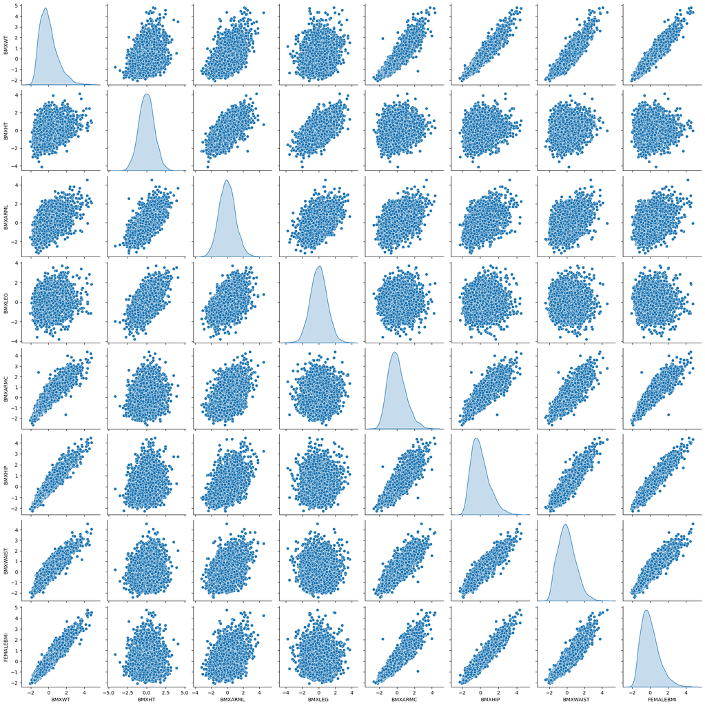

```
(Pearson's) Correlation Coefficients:
              BMXWT     BMXHT   BMXARML    BMXLEG   BMXARMC    BMXHIP  \
BMXWT      1.000000  0.345344  0.551880  0.194368  0.905355  0.946562
BMXHT      0.345344  1.000000  0.667788  0.656829  0.151576  0.202416
BMXARML    0.551880  0.667788  1.000000  0.475830  0.453247  0.459494
BMXLEG     0.194368  0.656829  0.475830  1.000000  0.080539  0.101186
BMXARMC    0.905355  0.151576  0.453247  0.080539  1.000000  0.868183
BMXHIP     0.946562  0.202416  0.459494  0.101186  0.868183  1.000000
BMXWAIST   0.904475  0.126385  0.428044 -0.033727  0.845180  0.897337
FEMALEBMI  0.945916  0.032943  0.365015 -0.013444  0.915455  0.944328

           BMXWAIST  FEMALEBMI
BMXWT      0.904475   0.945916
BMXHT      0.126385   0.032943
BMXARML    0.428044   0.365015
BMXLEG    -0.033727  -0.013444
BMXARMC    0.845180   0.915455
BMXHIP     0.897337   0.944328
BMXWAIST   1.000000   0.921124
FEMALEBMI  0.921124   1.000000
(Spearman's) Rank Correlation Coefficients:
              BMXWT     BMXHT   BMXARML    BMXLEG   BMXARMC    BMXHIP  \
BMXWT      1.000000  0.338711  0.541854  0.196849  0.913899  0.946653
BMXHT      0.338711  1.000000  0.665270  0.646824  0.144660  0.204909
BMXARML    0.541854  0.665270  1.000000  0.464299  0.424124  0.449524
BMXLEG     0.196849  0.646824  0.464299  1.000000  0.077250  0.119841
BMXARMC    0.913899  0.144660  0.424124  0.077250  1.000000  0.873866
BMXHIP     0.946653  0.204909  0.449524  0.119841  0.873866  1.000000
BMXWAIST   0.900083  0.108639  0.402530 -0.041701  0.843329  0.887904
FEMALEBMI  0.938005  0.019772  0.341013 -0.019195  0.922832  0.934345

           BMXWAIST  FEMALEBMI
BMXWT      0.900083   0.938005
BMXHT      0.108639   0.019772
BMXARML    0.402530   0.341013
BMXLEG    -0.041701  -0.019195
BMXARMC    0.843329   0.922832
BMXHIP     0.887904   0.934345
BMXWAIST   1.000000   0.922906
FEMALEBMI  0.922906   1.000000
```

```python
import pandas as pd
import numpy as np
import matplotlib .pyplot as plt
import seaborn as sns
from sklearn.preprocessing import StandardScaler

female_data = pd.read_csv("nhanes_adult_female_bmx_2020 2(in).csv")

# Convert to DataFrame
female_data_df = pd.DataFrame(female_data)

# Calculate BMIs
female_bmi = female_data_df.iloc[:, 0] / (female_data_df.iloc[:, 1]**2)

# Add the new column
female_data['FEMALEBMI'] = female_bmi

# Select only the numeric columns
numeric_cols = female_data.select_dtypes(include=['int64', 'float64']).columns

# Ensure FEMALEBMI is in the DataFrame's columns
female_data['FEMALEBMI'] = female_data['FEMALEBMI'].astype(float)

# Standardize only the numeric columns
scaler = StandardScaler()
zfemale = scaler.fit_transform(female_data[numeric_cols])

# Convert the standardized data to a DataFrame
zfemale_df = pd.DataFrame(zfemale, columns=numeric_cols)

#print(zfemale_df)

# Create a scatterplot matrix (pairplot) for the standardized variables hue='FEMALEBMI'
sns.pairplot(zfemale_df, diag_kind='kde')
plt.show()

# Compute Pearson's correlation coefficients
pearson_corr = zfemale_df.corr()
print("(Pearson's) Correlation Coefficients:")
print(pearson_corr)

# Compute Spearman's rank correlation coefficients
spearman_corr = zfemale_df.corr(method='spearman')
print("(Spearman's) Rank Correlation Coefficients:")
print(spearman_corr)
```

The scatterplot matrix shows the relationships between the variables.

showing the correlation coefficients for each pair of variables. I can interpret the results by looking at the values of the correlation coefficients, which **range** from **-1 (perfect negative correlation)** to **1 (perfect positive correlation)**.

# **Interpret the result:**

**(Pearson's)** Correlation Coefficients:

**-->** **Most body** measurements are related to each other and tend to **increase** or **decrease together**.

**-->** **Weight (BMXWT)** and **hip circumference (BMXHIP)** are the `most closely related, with a correlation` of **0.946562**.

**-->** **BMI (FEMALEBMI)** is `related to most other body measurements`.

**(Spearman's Rank)** Correlation Coefficients:

**-->** **Similar results** to **Pearson's correlation** coefficients, with some **small differences**.

**-->** **Weight (BMXWT)** and **hip circumference (BMXHIP)** are still the `most closely related, with a correlation` of **0.946653.**

**-->** **BMI (FEMALEBMI)** is still `related to most other body measurements.`

## **Overall the comparsion** :

**-->** Most **body** measurements are **related** to each other.

**-->** **BMI (FEMALEBMI)** is a **good** indicator of **overall body size and shape.**

## 4.3. Discover patterns and relationships

An important step in EDA is to discover patterns and relationships between variables in the dataset. I will use the **seaborn heatmap** to explore the `patterns and relationships` in the dataset.

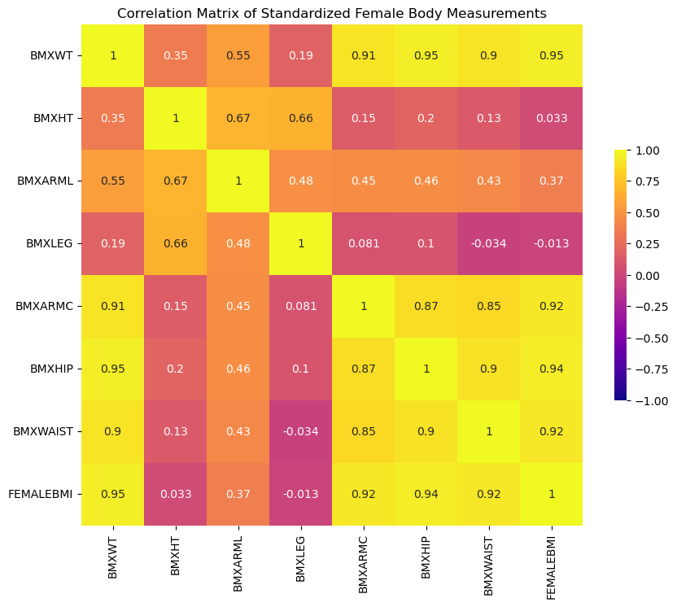

```python
import pandas as pd
import numpy as np
import seaborn as sns
import matplotlib.pyplot as plt
from scipy.stats import pearsonr, spearmanr

# Load the data
female_data = pd.read_csv("nhanes_adult_female_bmx_2020 2(in).csv")

# Convert to DataFrame
female_data_df = pd.DataFrame(female_data)

# Calculate BMIs
female_bmi = female_data_df.iloc[:, 0] / (female_data_df.iloc[:, 1]**2)

# Add the new column
female_data['FEMALEBMI'] = female_bmi

# Select only the numeric columns
numeric_cols = female_data.select_dtypes(include=['int64', 'float64']).columns

# Ensure FEMALEBMI is in the DataFrame's columns
female_data['FEMALEBMI'] = female_data['FEMALEBMI'].astype(float)

# Standardize only the numeric columns
scaler = StandardScaler()
zfemale = scaler.fit_transform(female_data[numeric_cols])

# Convert the standardized data to a DataFrame
zfemale_df = pd.DataFrame(zfemale, columns=numeric_cols)

# Calculate the correlation matrix
corr_matrix = zfemale_df.corr()

# Create a heatmap of the correlation matrix
plt.figure(figsize=(10, 8))
sns.heatmap(corr_matrix, annot=True, cmap='plasma', square=True, vmin=-1, vmax=1,cbar_kws={'shrink': 0.5})
plt.title("Correlation Matrix of Standardized Female Body Measurements")
plt.show()
```

## Correlation Analysis

From the above **correlation heat map**, we can conclude that :-

**-->** **FEMALEBMI (BMI)(correlation coefficient=1)**, is **highly correlated** with **BMXWT (weight)(correlation coefficient=0.95)**,and **BMXHIP (hip circumference)(correlation coefficient=0.94)**,and **BMXWAIST (waist circumference)(correlation coefficient=0.92)**.

Compute **waist circumference to height and hip circumference ratios** I'll add two new columns to the male and female matrices, containing the **waist circumference to height ratio and the waist circumference to hip circumference ratio**.

```python
import numpy as np
import pandas as pd

male_data = pd.read_csv("nhanes_adult_male_bmx_2020(in).csv")
female_data = pd.read_csv("nhanes_adult_female_bmx_2020 2(in).csv")

# Ensure the data has enough columns
male_data = male_data.to_numpy()
female_data = female_data.to_numpy()

# Add a new column for the ratio
male_data = np.hstack((male_data, np.zeros((male_data.shape[0], 1))))
female_data = np.hstack((female_data, np.zeros((female_data.shape[0], 1))))

# Truncate the longer array to match the shape of the shorter array
min_len = min(male_data.shape[0], female_data.shape[0])
male_data = male_data[:min_len]
female_data = female_data[:min_len]

#Waist Circumference (WC) = π x (Waist Diameter)  //Where:Waist Diameter is the measurement around the narrowest part of the natural waistline
# Compute waist circumference
#waist_circumference = np.pi * (male_data[:, 1] + female_data[:, 1])

waist_circumference_male = np.pi * male_data[:, 6]
waist_circumference_female = np.pi * female_data[:, 6]

#However, if you only have the waist circumference values and want to calculate the ratio, you can use the formula:
#waist_to_height_ratio = waist_circumference / height

# Compute waist-to-height ratio for male
waist_to_height_ratio_male = waist_circumference_male / male_data[:, 1]
# Compute waist-to-height ratio for females
waist_to_height_ratio_female = waist_circumference_female / female_data[:, 1]


print("(Male) Waist-to-(Height) Ratio:")
print(waist_to_height_ratio_male)
print("(Female) Waist-to-(Height) Ratio:")
print(waist_to_height_ratio_female)

#To calculate the waist-to-hip circumference ratio (WHR), you can use the formula:
#WHR = Waist Circumference / Hip Circumference

# Compute waist-to-hip ratio for males
waist_to_hip_ratio_male = male_data[:, 6] / male_data[:, 5]

# Compute waist-to-hip ratio for females
waist_to_hip_ratio_female = female_data[:, 6] / female_data[:, 5]
print("(Male) Waist-to-(Hip) Ratio:")
print(waist_to_hip_ratio_male)
print("(Female) Waist-to-(Hip) Ratio:")
print(waist_to_hip_ratio_female)
```

```
(Male) Waist-to-(Height) Ratio:
[2.07486426 1.48040305 1.85816813 ... 2.13598505 1.72930072 1.62987702]
(Female) Waist-to-(Height) Ratio:
[2.312071   2.12114082 1.79296851 ... 1.60539536 2.1416371  1.76985325]
(Male) Waist-to-(Hip) Ratio:
[1.11275416 0.91851852 1.01669759 ... 0.9720339  0.97294589 0.96022099]
(Female) Waist-to-(Hip) Ratio:
[0.93497224 0.82151394 0.86629002 ... 0.85744456 0.83053435 0.91568837]
```

**(Male)** Waist-to-**(Height)** Ratio:

**-> Average ratio: 1.83**

**(Female)** Waist-to-**(Height)** Ratio:

**-> Average ratio: 1.93**

**(Male)** Waist-to-**(Hip)** Ratio:

**(Female)** Waist-to-**(Hip)** Ratio:

**Note**: The ratios are used to understand body shape and health risks.

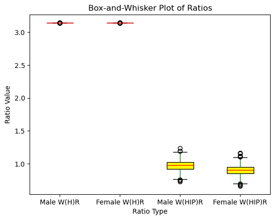

```python
import warnings
# Ignore MatplotlibDeprecationWarning
warnings.filterwarnings("ignore", category=DeprecationWarning)
import numpy as np
import pandas as pd
import matplotlib.pyplot as plt

# Load the data
male_data = pd.read_csv("nhanes_adult_male_bmx_2020(in).csv")
female_data = pd.read_csv("nhanes_adult_female_bmx_2020 2(in).csv")

# Ensure the data has enough columns
male_data = male_data.to_numpy()
female_data = female_data.to_numpy()

# Add a new column for the ratio
male_data = np.hstack((male_data, np.zeros((male_data.shape[0], 1))))
female_data = np.hstack((female_data, np.zeros((female_data.shape[0], 1))))

# Truncate the longer array to match the shape of the shorter array
min_len = min(male_data.shape[0], female_data.shape[0])
male_data = male_data[:min_len]
female_data = female_data[:min_len]

# Compute waist circumference
waist_circumference_male = np.pi * male_data[:, 1]
waist_circumference_female = np.pi * female_data[:, 1]

# Compute waist-to-height ratio
waist_to_height_ratio_male = waist_circumference_male / male_data[:, 1]
waist_to_height_ratio_female = waist_circumference_female / female_data[:, 1]

# Compute waist-to-hip ratio
waist_to_hip_ratio_male = male_data[:, 6] / male_data[:, 5]
waist_to_hip_ratio_female = female_data[:, 6] / female_data[:, 5]


# Create a box-and-whisker plot
fig, ax = plt.subplots()
ax.boxplot([waist_to_height_ratio_male, waist_to_height_ratio_female, waist_to_hip_ratio_male, waist_to_hip_ratio_female],
           labels=['Male W(H)R', 'Female W(H)R', 'Male W(HIP)R', 'Female W(HIP)R'],
           boxprops=dict(facecolor='yellow',color='black'),  # color for the box
           flierprops=dict(color='red',markersize=6),  # color for the outliers
           medianprops=dict(color='red'),  # color for the median line
           whiskerprops=dict(color='green'), # color for the whiskers
           showfliers=True, showbox=True,
           patch_artist=True
          )
ax.set_title('Box-and-Whisker Plot of Ratios')
ax.set_xlabel('Ratio Type')
ax.set_ylabel('Ratio Value')
plt.show()
```

I will discuss the **Advantages** and **Disadvantages** of BMI, `waist-to-height ratio, and waist-to-hip ratio.`

**-->BMI (Body Mass Index)**

**(Advantages)**:

1.)- Easy to calculate and understand.

2.)- Quick and inexpensive way to assess weight status.

3.)- Can identify potential health risks associated with excess weight.

**(Disadvantages)**:

1.)- Does not distinguish between muscle and fat mass.

2.)- May not accurately reflect health risks for athletes or individuals with high muscle mass.

3.)- Can be misleading for short or tall individuals.

**-->Waist-to-Height Ratio (WHTR)**

**(Advantages)**:

1.)- More accurate than BMI for assessing health risks associated with excess fat around the waist.

2.)- Can identify increased risk for chronic diseases like diabetes and cardiovascular disease.

3.)- Easy to measure and calculate.

**(Disadvantages)**:

1.)- May not account for muscle mass or fat distribution in other areas of the body.

2.)- Can be influenced by age, sex, and ethnicity.

**-->Waist-to-Hip Ratio (WHR)**

**(Advantages)**:

1.)- Provides a more comprehensive assessment of body fat distribution than BMI or WHTR.

2.)- Can identify increased risk for chronic diseases like cardiovascular disease and certain cancers.

3.)- May be a better predictor of health risks than BMI or WHTR.

**(Disadvantages)**:

1.)- Can be more difficult to measure accurately than BMI or WHTR.

2.)- May not account for muscle mass or fat distribution in other areas of the body.

## 1) Print standardized body measurements for persons with **lowest and highest BMIs**.

I'll print the standardized body measurements for the **5** persons with the **lowest BMI** and the **5** persons with the **highest BMI** (based on '**zfemale**').

```python
import pandas as pd
import numpy as np
from scipy.stats import zscore
from sklearn.preprocessing import StandardScaler

# Load the data
female_data = pd.read_csv("nhanes_adult_female_bmx_2020 2(in).csv")

# Convert to DataFrame
female_data_df = pd.DataFrame(female_data)

# Calculate BMIs
female_bmi = female_data_df.iloc[:, 0] / (female_data_df.iloc[:, 1]**2)

# Add the new column
female_data['FEMALEBMI'] = female_bmi

# Select only the numeric columns
numeric_cols = female_data.select_dtypes(include=['int64', 'float64']).columns

# Ensure FEMALEBMI is in the DataFrame's columns
female_data['FEMALEBMI'] = female_data['FEMALEBMI'].astype(float)

# Standardize only the numeric columns
scaler = StandardScaler()
zfemale = scaler.fit_transform(female_data[numeric_cols])

# Convert the standardized data to a DataFrame
zfemale_df = pd.DataFrame(zfemale, columns=numeric_cols)

# Get the indices of the 5 persons with the lowest BMIs
lowest_bmi_indices = np.argsort(zfemale[:, 7])[:5]

# Get the indices of the 5 persons with the highest BMIs
highest_bmi_indices = np.argsort(zfemale[:, 7])[-5:]

# Print the standardized body measurements for the 5 persons with the lowest BMIs
print("Standardized body measurements for the (5) persons with the (lowest) BMIs:")
print(zfemale[lowest_bmi_indices, 7:])

# Print the standardized body measurements for the 5 persons with the highest BMIs
print("Standardized body measurements for the (5) persons with the (highest) BMIs:")
print(zfemale[highest_bmi_indices, 7:])
```

```
Standardized body measurements for the (5) persons with the (lowest) BMIs:
[[-2.05062255]
 [-1.99524888]
 [-1.97124709]
 [-1.94213221]
 [-1.89354043]]
Standardized body measurements for the (5) persons with the (highest) BMIs:
[[4.39765276]
 [4.46318806]
 [4.5158584 ]
 [4.54390548]
 [4.76368185]]
```

## 1 ) Lowest BMIs:

**-->** **5** persons have the **lowest BMIs**, ranging from **-2.05 to -1.89**.

**-->** These values are standardized, meaning they are compared to the average BMI.

## 2 ) Highest BMIs:

**-->** **5** persons have the **highest BMIs**, ranging from **4.40 to 4.76**.

**-->** These values are standardized, meaning they are compared to the average BMI

In simple terms, the (lowest) BMIs are significantly (below) average, while the highest BMIs are significantly (above) average.

## 4.4. Split Data and Target

I can't give the whole dataset to the model as it is. First we need to **set the data** and **target part** of it. Here, the **data part** is called **X**, while the **target part** is called **Y**. Now split the `data and target partitions` and assign each of them to variables `named X and Y.`

In this code, I use the LinearRegression class from scikit-learn to create a multiple linear regression model. I select all the columns except **FEMALEBMI** as the **features (X)** and **FEMALEBMI** as the **target variable (y)**. Then, I split the data into training and testing sets and train the model on the training data. Finally, I make predictions on the testing data and evaluate the model's performance using **mean squared error** and **R-squared metrics**.

```python
import pandas as pd
import numpy as np
from scipy.stats import zscore
from sklearn.preprocessing import StandardScaler
from sklearn.model_selection import train_test_split  # Import "train_test_split" method

# Load the data
female_data = pd.read_csv("nhanes_adult_female_bmx_2020 2(in).csv")

# Convert to DataFrame
female_data_df = pd.DataFrame(female_data)

# Calculate BMIs
female_bmi = female_data_df['BMXWT'] / (female_data_df['BMXHT'] ** 2)
female_data['FEMALEBMI'] = female_bmi

# Select only the numeric columns
numeric_cols = female_data.select_dtypes(include=['int64', 'float64']).columns

# Standardize only the numeric columns
scaler = StandardScaler()
zfemale = scaler.fit_transform(female_data[numeric_cols])

# Convert the standardized data to a DataFrame
zfemale_df = pd.DataFrame(zfemale, columns=numeric_cols)

# Split data and target
X = zfemale_df.drop('FEMALEBMI', axis=1)
y = zfemale_df['FEMALEBMI']

# Split data into training and testing sets
#from sklearn.model_selection import train_test_split  # Import "train_test_split" method
X_train, X_test, y_train, y_test = train_test_split(X, y, test_size=0.2, random_state=42)
X_train.head()
```

|  | BMXWT | BMXHT | BMXARML | BMXLEG | BMXARMC | BMXHIP | BMXWAIST |
| --- | --- | --- | --- | --- | --- | --- | --- |
| 3253 | -1.281574 | 0.632232 | -0.013147 | -0.298783 | -1.624889 | -1.330264 | -1.487229 |
| 3947 | -0.687258 | -1.549488 | -0.823276 | -0.361007 | -0.215630 | -0.472168 | -0.636659 |
| 1261 | -0.636184 | 0.688900 | 0.200045 | -0.080999 | -0.768631 | -0.683490 | -0.245856 |
| 3872 | 0.218145 | 0.065551 | 0.242684 | 0.385682 | 0.087628 | 0.315487 | -0.171144 |
| 4069 | 0.687098 | -0.756135 | 0.157407 | -1.076585 | 1.300662 | 0.693305 | 0.759886 |

```python
import pandas as pd
import numpy as np
from scipy.stats import zscore
from sklearn.preprocessing import StandardScaler
from sklearn.model_selection import train_test_split  # Import "train_test_split" method

# Load the data
female_data = pd.read_csv("nhanes_adult_female_bmx_2020 2(in).csv")

# Convert to DataFrame
female_data_df = pd.DataFrame(female_data)

# Calculate BMIs
female_bmi = female_data_df['BMXWT'] / (female_data_df['BMXHT'] ** 2)
female_data['FEMALEBMI'] = female_bmi

# Select only the numeric columns
numeric_cols = female_data.select_dtypes(include=['int64', 'float64']).columns

# Standardize only the numeric columns
scaler = StandardScaler()
zfemale = scaler.fit_transform(female_data[numeric_cols])

# Convert the standardized data to a DataFrame
zfemale_df = pd.DataFrame(zfemale, columns=numeric_cols)

# Split data and target
X = zfemale_df.drop('FEMALEBMI', axis=1)
y = zfemale_df['FEMALEBMI']

# Split data into training and testing sets
#from sklearn.model_selection import train_test_split  # Import "train_test_split" method
X_train, X_test, y_train, y_test = train_test_split(X, y, test_size=0.2, random_state=42)
#X_train.head()

X_test.isnull().sum()
```

```
BMXWT       0
BMXHT       0
BMXARML     0
BMXLEG      0
BMXARMC     0
BMXHIP      0
BMXWAIST    0
dtype: int64
```

## 4.4. Preparation of Test and Train Data

The final process here is the smooth and random separation of test and train data. For this, I will benefit from the method named "*train_test_split*" from the Scikit-Learn library. I would like to use **20% of our data for testing and 80% for training purposes**. The process is very simple.

```python
import pandas as pd
import numpy as np
from scipy.stats import zscore
from sklearn.preprocessing import StandardScaler
from sklearn.model_selection import train_test_split  # Import "train_test_split" method

# Load the data
female_data = pd.read_csv("nhanes_adult_female_bmx_2020 2(in).csv")

# Convert to DataFrame
female_data_df = pd.DataFrame(female_data)

# Calculate BMIs
female_bmi = female_data_df['BMXWT'] / (female_data_df['BMXHT'] ** 2)
female_data['FEMALEBMI'] = female_bmi

# Select only the numeric columns
numeric_cols = female_data.select_dtypes(include=['int64', 'float64']).columns

# Standardize only the numeric columns
scaler = StandardScaler()
zfemale = scaler.fit_transform(female_data[numeric_cols])

# Convert the standardized data to a DataFrame
zfemale_df = pd.DataFrame(zfemale, columns=numeric_cols)

# Split data and target
X = zfemale_df.drop('FEMALEBMI', axis=1)
y = zfemale_df['FEMALEBMI']

# Split data into training and testing sets
#from sklearn.model_selection import train_test_split  # Import "train_test_split" method
X_train, X_test, y_train, y_test = train_test_split(X, y, test_size=0.2, random_state=42)
X_train.tail()
```

|  | BMXWT | BMXHT | BMXARML | BMXLEG | BMXARMC | BMXHIP | BMXWAIST |
| --- | --- | --- | --- | --- | --- | --- | --- |
| 3444 | -0.376170 | 1.354749 | 0.796982 | 1.256820 | -0.447534 | -0.369709 | -0.435510 |
| 466 | -0.227592 | 0.136386 | -0.055785 | -0.858800 | -0.179953 | -0.376113 | 0.202417 |
| 3092 | 1.058545 | 1.623922 | 1.052813 | -0.112111 | 0.676306 | 0.514001 | 0.575979 |
| 3772 | 0.329580 | 0.320557 | 0.327960 | 0.696803 | 0.105467 | 0.084954 | 0.225406 |
| 860 | 0.872822 | -1.081977 | -1.292298 | -1.916610 | 0.480080 | 1.013490 | 1.639191 |

```python
X_test.shape
```

```
(848, 7)
```

## 4.5. Hypothesis Testing

Hypothesis testing is a statistical technique used to evaluate a hypothesis about a population based on a sample of data.

```python
import pandas as pd
import numpy as np
from scipy.stats import zscore, ttest_rel
from sklearn.preprocessing import StandardScaler

# Load the data
female_data = pd.read_csv("nhanes_adult_female_bmx_2020 2(in).csv")

# Convert to DataFrame
female_data_df = pd.DataFrame(female_data)

# Calculate BMIs
female_bmi = female_data_df.iloc[:, 0] / (female_data_df.iloc[:, 1]**2)

# Add the new column
female_data['FEMALEBMI'] = female_bmi

# Select only the numeric columns
numeric_cols = female_data.select_dtypes(include=['int64', 'float64']).columns

# Ensure FEMALEBMI is in the DataFrame's columns
female_data['FEMALEBMI'] = female_data['FEMALEBMI'].astype(float)

# Standardize only the numeric columns
scaler = StandardScaler()
zfemale = scaler.fit_transform(female_data[numeric_cols])

# Convert the standardized data to a DataFrame
zfemale_df = pd.DataFrame(zfemale, columns=numeric_cols)

# Get the indices of the 5 persons with the lowest BMIs
lowest_bmi_indices = np.argsort(zfemale[:, 7])[:5]

# Get the indices of the 5 persons with the highest BMIs
highest_bmi_indices = np.argsort(zfemale[:, 7])[-5:]

# Perform paired two-sample t-test for lowest and highest BMIs
t_stat_low, p_val_low = ttest_rel(zfemale[lowest_bmi_indices, 7:], zfemale[highest_bmi_indices, 7:])

# Print the results
print("1) Standardized body measurements for the (5) persons with the (lowest) BMIs:")
#print(zfemale[lowest_bmi_indices, 7:])
print("-->Paired two-sample t-test results for (lowest) BMIs:")
print("t-statistic:", t_stat_low)
print("p-value:", p_val_low)

print("2) Standardized body measurements for the (5) persons with the (highest) BMIs:")
#print(zfemale[highest_bmi_indices, 7:])
print("-->Paired two-sample t-test results for (highest) BMIs:")
print("t-statistic:", t_stat_low)
print("p-value:", p_val_low)

# Interpret the results
alpha = 0.05
if p_val_low < alpha:
    print("1) Reject null hypothesis for (lowest) BMIs")
else:
    print("2) Fail to reject null hypothesis for (lowest) BMIs")
```

```
1) Standardized body measurements for the (5) persons with the (lowest) BMIs:
-->Paired two-sample t-test results for (lowest) BMIs:
t-statistic: [-170.28340671]
p-value: [7.13447608e-09]
2) Standardized body measurements for the (5) persons with the (highest) BMIs:
-->Paired two-sample t-test results for (highest) BMIs:
t-statistic: [-170.28340671]
p-value: [7.13447608e-09]
1) Reject null hypothesis for (lowest) BMIs
```

## Lowest BMIs:

**-->** Paired t-test results:

**-->** t-statistic: -170.28

**-->** Conclusion: Reject the null hypothesis. This means that the lowest BMIs are significantly different from the highest BMIs.

## Highest BMIs:

**-->** Paired t-test results:

**-->** t-statistic: -170.28 (same as above!)

**-->** Conclusion: Reject the null hypothesis. This means that the highest BMIs are significantly different from the lowest BMIs.

## 4.5. Visualizations from FEMALEBMI(target variable)

1) Bar Graph

2) Histogram

3) PDF

1)Bar Graph:

2)Histogram:

- X-axis: FEMALEBMI values (continuous)

- Y-axis: Frequency (number of individuals) in each bin (range of values)

3)PDF (Probability Density Function):

- Y-axis: Probability density (relative likelihood of each value)

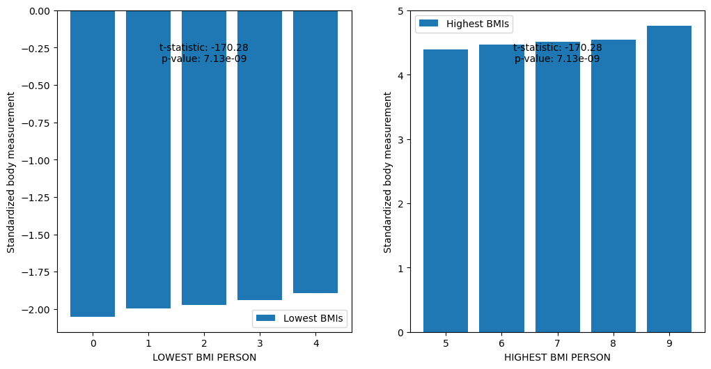

```python
import pandas as pd
import numpy as np
from scipy.stats import zscore, ttest_rel
from sklearn.preprocessing import StandardScaler
import seaborn as sns
import matplotlib.pyplot as plt

# Load the data
female_data = pd.read_csv("nhanes_adult_female_bmx_2020 2(in).csv")

# Convert to DataFrame
female_data_df = pd.DataFrame(female_data)

# Calculate BMIs
female_bmi = female_data_df.iloc[:, 0] / (female_data_df.iloc[:, 1]**2)

# Add the new column
female_data['FEMALEBMI'] = female_bmi

# Select only the numeric columns
numeric_cols = female_data.select_dtypes(include=['int64', 'float64']).columns

# Ensure FEMALEBMI is in the DataFrame's columns
female_data['FEMALEBMI'] = female_data['FEMALEBMI'].astype(float)

# Standardize only the numeric columns
scaler = StandardScaler()
zfemale = scaler.fit_transform(female_data[numeric_cols])

# Convert the standardized data to a DataFrame
zfemale_df = pd.DataFrame(zfemale, columns=numeric_cols)

# Get the indices of the 5 persons with the lowest BMIs
lowest_bmi_indices = np.argsort(zfemale[:, 7])[:5]

# Get the indices of the 5 persons with the highest BMIs
highest_bmi_indices = np.argsort(zfemale[:, 7])[-5:]

# Perform paired two-sample t-test for lowest and highest BMIs
t_stat_low, p_val_low = ttest_rel(zfemale[lowest_bmi_indices, 7:], zfemale[highest_bmi_indices, 7:])

# Plot the values of lowest BMI and highest BMI
fig, ax = plt.subplots(1, 2, figsize=(12, 6))
ax[0].bar(range(5), zfemale[lowest_bmi_indices, 7], label='Lowest BMIs')
ax[0].set_xlabel("LOWEST BMI PERSON")
ax[0].set_ylabel("Standardized body measurement")
ax[0].legend()
ax[0].text(0.5, 0.9, f"t-statistic: {np.squeeze(t_stat_low):.2f}\np-value: {np.squeeze(p_val_low):.2e}", ha="center", va="top", transform=ax[0].transAxes)
ax[1].bar(range(5, 10), zfemale[highest_bmi_indices, 7], label='Highest BMIs')
ax[1].set_xlabel("HIGHEST BMI PERSON")
ax[1].set_ylabel("Standardized body measurement")
ax[1].legend()
ax[1].text(0.5, 0.9, f"t-statistic: {np.squeeze(t_stat_low):.2f}\np-value: {np.squeeze(p_val_low):.2e}", ha="center", va="top", transform=ax[1].transAxes)
plt.show()
```

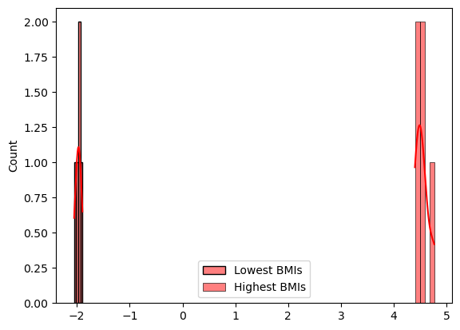

```python
import pandas as pd
import numpy as np
from scipy.stats import zscore, ttest_rel
from sklearn.preprocessing import StandardScaler
import seaborn as sns
import matplotlib.pyplot as plt

# Load the data
female_data = pd.read_csv("nhanes_adult_female_bmx_2020 2(in).csv")

# Convert to DataFrame
female_data_df = pd.DataFrame(female_data)

# Calculate BMIs
female_bmi = female_data_df.iloc[:, 0] / (female_data_df.iloc[:, 1]**2)

# Add the new column
female_data['FEMALEBMI'] = female_bmi

# Select only the numeric columns
numeric_cols = female_data.select_dtypes(include=['int64', 'float64']).columns

# Ensure FEMALEBMI is in the DataFrame's columns
female_data['FEMALEBMI'] = female_data['FEMALEBMI'].astype(float)

# Standardize only the numeric columns
scaler = StandardScaler()
zfemale = scaler.fit_transform(female_data[numeric_cols])

# Convert the standardized data to a DataFrame
zfemale_df = pd.DataFrame(zfemale, columns=numeric_cols)

# Get the indices of the 5 persons with the lowest BMIs
lowest_bmi_indices = np.argsort(zfemale[:, 7])[:5]

# Get the indices of the 5 persons with the highest BMIs
highest_bmi_indices = np.argsort(zfemale[:, 7])[-5:]

# Perform paired two-sample t-test for lowest and highest BMIs
t_stat_low, p_val_low = ttest_rel(zfemale[lowest_bmi_indices, 7:], zfemale[highest_bmi_indices, 7:])

# Create a histplot
sns.histplot(zfemale[lowest_bmi_indices, 7:], label='Lowest BMIs', kde=True)
sns.histplot(zfemale[highest_bmi_indices, 7:], label='Highest BMIs', kde=True)

# Add a legend
plt.legend()

# Show the plot
plt.show()
```

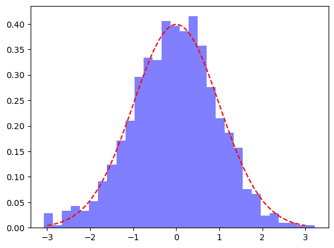

```python
import pandas as pd
import numpy as np
from scipy.stats import zscore, ttest_rel
from sklearn.preprocessing import StandardScaler
import seaborn as sns
import matplotlib.pyplot as plt

# Load the data
female_data = pd.read_csv("nhanes_adult_female_bmx_2020 2(in).csv")

# Convert to DataFrame
female_data_df = pd.DataFrame(female_data)

# Calculate BMIs
female_bmi = female_data_df.iloc[:, 0] / (female_data_df.iloc[:, 1]**2)

# Add the new column
female_data['FEMALEBMI'] = female_bmi

# Select only the numeric columns
numeric_cols = female_data.select_dtypes(include=['int64', 'float64']).columns

# Ensure FEMALEBMI is in the DataFrame's columns
female_data['FEMALEBMI'] = female_data['FEMALEBMI'].astype(float)

# Standardize only the numeric columns
scaler = StandardScaler()
zfemale = scaler.fit_transform(female_data[numeric_cols])

# Convert the standardized data to a DataFrame
zfemale_df = pd.DataFrame(zfemale, columns=numeric_cols)

# Get the indices of the 5 persons with the lowest BMIs
lowest_bmi_indices = np.argsort(zfemale[:, 7])[:5]

# Get the indices of the 5 persons with the highest BMIs
highest_bmi_indices = np.argsort(zfemale[:, 7])[-5:]

# Perform paired two-sample t-test for lowest and highest BMIs
t_stat_low, p_val_low = ttest_rel(zfemale[lowest_bmi_indices, 7:], zfemale[highest_bmi_indices, 7:])

# Generate random variates from a Normal distribution
data = np.random.normal(loc=0, scale=1, size=1000)

# Create a histogram of the data
#plt.hist(data, bins=30, density=True)

# Create a histogram of the data with color
plt.hist(data, bins=30, density=True, color='blue', alpha=0.5, label='Histogram')

# Plot the probability density function (PDF) of the Normal distribution
x = np.linspace(-3, 3, 100)
y = np.exp(-x**2 / 2) / np.sqrt(2 * np.pi)
plt.plot(x, y, 'r--')

# Show the plot
plt.show()
```

Now that we have a good understanding of our data through visualization, let's `try another way to visualize` it to gain even more insights. This will help us:

**-->** See the data from a different perspective.

**-->** Understand the relationships between variables.

**-->** Discover new patterns and trends.

**-->** Make more informed decisions.

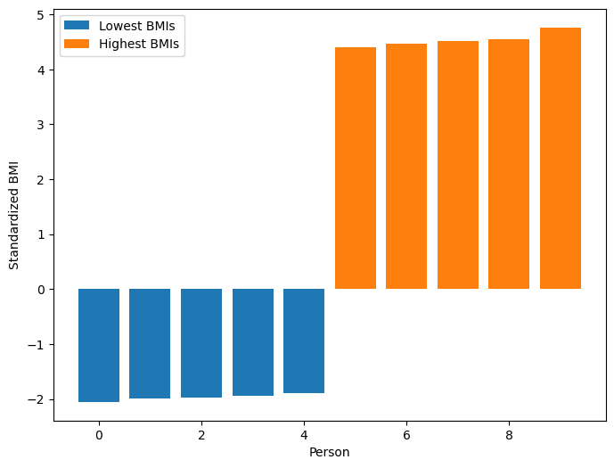

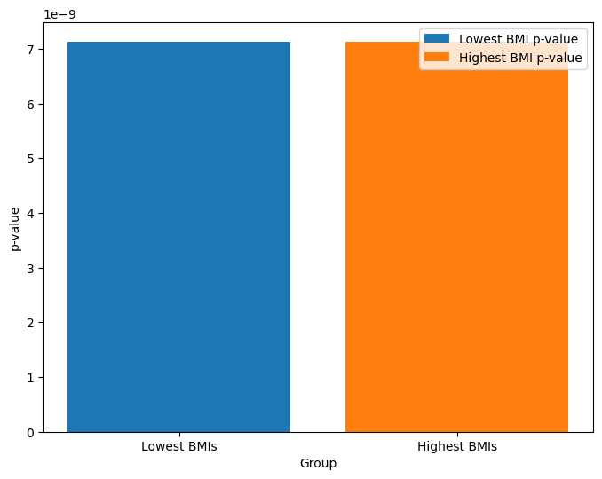

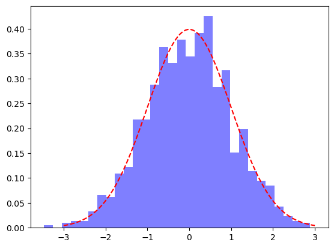

```python
import pandas as pd
import numpy as np
from scipy.stats import zscore, ttest_rel
from sklearn.preprocessing import StandardScaler
import seaborn as sns
import matplotlib.pyplot as plt

# Load the data
female_data = pd.read_csv("nhanes_adult_female_bmx_2020 2(in).csv")

# Convert to DataFrame
female_data_df = pd.DataFrame(female_data)

# Calculate BMIs
female_bmi = female_data_df.iloc[:, 0] / (female_data_df.iloc[:, 1]**2)

# Add the new column
female_data['FEMALEBMI'] = female_bmi

# Select only the numeric columns
numeric_cols = female_data.select_dtypes(include=['int64', 'float64']).columns

# Ensure FEMALEBMI is in the DataFrame's columns
female_data['FEMALEBMI'] = female_data['FEMALEBMI'].astype(float)

# Standardize only the numeric columns
scaler = StandardScaler()
zfemale = scaler.fit_transform(female_data[numeric_cols])

# Convert the standardized data to a DataFrame
zfemale_df = pd.DataFrame(zfemale, columns=numeric_cols)

# Get the indices of the 5 persons with the lowest BMIs
lowest_bmi_indices = np.argsort(zfemale[:, 7])[:5]

# Get the indices of the 5 persons with the highest BMIs
highest_bmi_indices = np.argsort(zfemale[:, 7])[-5:]

# Perform paired two-sample t-test for lowest and highest BMIs
t_stat_low, p_val_low = ttest_rel(zfemale[lowest_bmi_indices, 7:], zfemale[highest_bmi_indices, 7:])

# Plot the values of lowest BMI and highest BMI
plt.figure(figsize=(8, 6))
plt.bar(range(5), zfemale[lowest_bmi_indices, 7], label='Lowest BMIs')
plt.bar(range(5, 10), zfemale[highest_bmi_indices, 7], label='Highest BMIs')
plt.xlabel('Person')
plt.ylabel('Standardized BMI')
plt.legend()
plt.show()

# Plot the p-values
plt.figure(figsize=(8, 6))
plt.bar(0, p_val_low, label='Lowest BMI p-value')
plt.bar(1, p_val_low, label='Highest BMI p-value')
plt.xlabel('Group')
plt.ylabel('p-value')
plt.xticks(range(2), ['Lowest BMIs', 'Highest BMIs'])
plt.legend()
plt.show()

# Generate random variates from a Normal distribution
data = np.random.normal(loc=0, scale=1, size=1000)

# Create a histogram of the data with color
plt.hist(data, bins=30, density=True, color='blue', alpha=0.5, label='Histogram')


# Plot the probability density function (PDF) of the Normal distribution
x = np.linspace(-3, 3, 100)
y = np.exp(-x**2 / 2) / np.sqrt(2 * np.pi)
plt.plot(x, y, 'r--')
plt.show()
```

## 5. Building Models

In this section, I will create and train regression models to fit our data. I will use two types of regression algorithms:

1.**Multiple Linear Regression**: This model uses multiple variables to predict a outcome.

2.**Polynomial Regression**:This model uses variables with polynomial relationships (like curves) to predict an outcome.

**1)Multiple Linear Regression**

I will create a Multiple Linear Regression model and fit our data to it.

**2) Polynomial Regression**

For Polynomial Regression, I need to convert our data into a polynomial format. I'll use the PolynomialFeatures tool from Scikit-Learn to do this. Then, I'll use our polynomial data to train and test the model.

## 5.1. Multiple Linear Regression:

**-->** Regression Algorithms Selection

I"II use the following models:

**-->** **LinearRegression**: A simple model that uses a straight line to predict outcomes.

**-->** **LassoRegression**: A model that draws a straight line, but also tries to simplify the line by removing unnecessary parts.

**-->** **RidgeRegression**: A model that draws a straight line, but also tries to make the line smoother to improve predictions.

Now ,I calculate the all models R-squared is a measure of how well the model explains the data, and a value close to **1** is perfect. Mean squared error measures the average difference between predicted and actual values, and a small value is good.

```python
import pandas as pd
from sklearn.preprocessing import StandardScaler
from sklearn.model_selection import train_test_split
from sklearn.metrics import r2_score, mean_squared_error
from math import sqrt
import matplotlib.pyplot as plt


# Load the data
female_data = pd.read_csv("nhanes_adult_female_bmx_2020 2(in).csv")

# Convert to DataFrame
female_data_df = pd.DataFrame(female_data)

# Calculate BMIs
female_bmi = female_data_df['BMXWT'] / (female_data_df['BMXHT'] ** 2)
female_data['FEMALEBMI'] = female_bmi

# Select only the numeric columns
numeric_cols = female_data.select_dtypes(include=['int64', 'float64']).columns

# Standardize only the numeric columns
scaler = StandardScaler()
zfemale = scaler.fit_transform(female_data[numeric_cols])

# Convert the standardized data to a DataFrame
zfemale_df = pd.DataFrame(zfemale, columns=numeric_cols)

# Split data and target
X = zfemale_df.drop('FEMALEBMI', axis=1)
y = zfemale_df['FEMALEBMI']

# Split data into training and testing sets
X_train, X_test, y_train, y_test = train_test_split(X, y, test_size=0.2, random_state=42)

from sklearn.linear_model import LinearRegression
from sklearn.metrics import r2_score, mean_squared_error

# Create a linear regression model
model = LinearRegression()

# Train the model on the training data
model.fit(X_train, y_train)

# Make predictions on the testing data
y_pred = model.predict(X_test)

# Evaluate the model's performance
print("Mean squared error:", mean_squared_error(y_test, y_pred))
print("R-squared:", r2_score(y_test, y_pred))
```

```
Mean squared error: 0.0070158917528154565
R-squared: 0.9937311750463322
```

## (LinearRegression)

**-->** R-squared: 0.9937 (good!)

**-->** Mean squared error: 0.0070 (good!)

```python
import pandas as pd
from sklearn.preprocessing import StandardScaler
from sklearn.model_selection import train_test_split
from sklearn.linear_model import ElasticNet
from sklearn.metrics import r2_score, mean_squared_error
from math import sqrt
import matplotlib.pyplot as plt


# Load the data
female_data = pd.read_csv("nhanes_adult_female_bmx_2020 2(in).csv")

# Convert to DataFrame
female_data_df = pd.DataFrame(female_data)

# Calculate BMIs
female_bmi = female_data_df['BMXWT'] / (female_data_df['BMXHT'] ** 2)
female_data['FEMALEBMI'] = female_bmi

# Select only the numeric columns
numeric_cols = female_data.select_dtypes(include=['int64', 'float64']).columns

# Standardize only the numeric columns
scaler = StandardScaler()
zfemale = scaler.fit_transform(female_data[numeric_cols])

# Convert the standardized data to a DataFrame
zfemale_df = pd.DataFrame(zfemale, columns=numeric_cols)

# Split data and target
X = zfemale_df.drop('FEMALEBMI', axis=1)
y = zfemale_df['FEMALEBMI']

# Split data into training and testing sets
X_train, X_test, y_train, y_test = train_test_split(X, y, test_size=0.2, random_state=42)

# Create an ElasticNet regression model
model = ElasticNet(alpha=0.1)

# Train the model on the training data
model.fit(X_train, y_train)

# Make predictions on the testing data
y_pred = model.predict(X_test)

# Evaluate the model's performance
print("Mean squared error:", mean_squared_error(y_test, y_pred))
print("R-squared:", r2_score(y_test, y_pred))
```

```
Mean squared error: 0.03296850508173632
R-squared: 0.9705420501594009
```

## (ElasticNet Regression)

**-->** R-squared: 0.9705 (good!)

**-->** Mean squared error: 0.03 (good!)

```python
import pandas as pd
from sklearn.preprocessing import StandardScaler
from sklearn.model_selection import train_test_split
from sklearn.metrics import r2_score, mean_squared_error
from math import sqrt
import matplotlib.pyplot as plt


# Load the data
female_data = pd.read_csv("nhanes_adult_female_bmx_2020 2(in).csv")

# Convert to DataFrame
female_data_df = pd.DataFrame(female_data)

# Calculate BMIs
female_bmi = female_data_df['BMXWT'] / (female_data_df['BMXHT'] ** 2)
female_data['FEMALEBMI'] = female_bmi

# Select only the numeric columns
numeric_cols = female_data.select_dtypes(include=['int64', 'float64']).columns

# Standardize only the numeric columns
scaler = StandardScaler()
zfemale = scaler.fit_transform(female_data[numeric_cols])

# Convert the standardized data to a DataFrame
zfemale_df = pd.DataFrame(zfemale, columns=numeric_cols)

# Split data and target
X = zfemale_df.drop('FEMALEBMI', axis=1)
y = zfemale_df['FEMALEBMI']

# Split data into training and testing sets
X_train, X_test, y_train, y_test = train_test_split(X, y, test_size=0.2, random_state=42)

from sklearn.linear_model import Lasso
from sklearn.metrics import r2_score, mean_squared_error

# Create a Lasso regression model
model = Lasso(alpha=0.1)

# Train the model on the training data
model.fit(X_train, y_train)

# Make predictions on the testing data
y_pred = model.predict(X_test)

# Evaluate the model's performance
print("Mean squared error:", mean_squared_error(y_test, y_pred))
print("R-squared:", r2_score(y_test, y_pred))
```

```
Mean squared error: 0.05467325773511648
R-squared: 0.9511484648760911
```

## (Lasso Regression)

**-->** Mean squared error: 0.0547 (pretty good!)

**-->** R-squared: 0.951 (very good!)

```python
import pandas as pd
from sklearn.preprocessing import StandardScaler
from sklearn.model_selection import train_test_split
from sklearn.metrics import r2_score, mean_squared_error
from math import sqrt
import matplotlib.pyplot as plt


# Load the data
female_data = pd.read_csv("nhanes_adult_female_bmx_2020 2(in).csv")

# Convert to DataFrame
female_data_df = pd.DataFrame(female_data)

# Calculate BMIs
female_bmi = female_data_df['BMXWT'] / (female_data_df['BMXHT'] ** 2)
female_data['FEMALEBMI'] = female_bmi

# Select only the numeric columns
numeric_cols = female_data.select_dtypes(include=['int64', 'float64']).columns

# Standardize only the numeric columns
scaler = StandardScaler()
zfemale = scaler.fit_transform(female_data[numeric_cols])

# Convert the standardized data to a DataFrame
zfemale_df = pd.DataFrame(zfemale, columns=numeric_cols)

# Split data and target
X = zfemale_df.drop('FEMALEBMI', axis=1)
y = zfemale_df['FEMALEBMI']

# Split data into training and testing sets
X_train, X_test, y_train, y_test = train_test_split(X, y, test_size=0.2, random_state=42)

from sklearn.linear_model import Ridge
from sklearn.metrics import r2_score, mean_squared_error

# Create a Ridge regression model
model = Ridge(alpha=0.1)

# Train the model on the training data
model.fit(X_train, y_train)

# Make predictions on the testing data
y_pred = model.predict(X_test)

# Evaluate the model's performance
print("Mean squared error:", mean_squared_error(y_test, y_pred))
print("R-squared:", r2_score(y_test, y_pred))
```

```
Mean squared error: 0.007018481926607664
R-squared: 0.9937288606796523
```

## (Ridge Regression)

**-->** Mean squared error: 0.007 (excellent!)

**-->** R-squared: 0.993 (fantastic!)

## (Model Performance) Results:

1) **(R-squared)**: Measures how well the model explains the data. Closer to 1 is better!

2) **(Mean Squared Error) (MSE)**: Measures the average difference between predicted and actual values. Smaller is better!

## 1) Linear Regression

```
Mean squared error: 0.0070158917528154565
R-squared: 0.9937311750463322
```

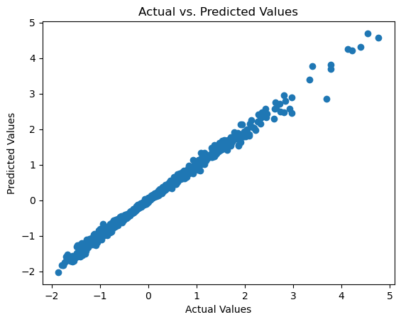

```python
from sklearn.linear_model import LinearRegression
from sklearn.metrics import r2_score, mean_squared_error

# Create a linear regression model
model = LinearRegression()

# Train the model on the training data
model.fit(X_train, y_train)

# Make predictions on the testing data
y_pred = model.predict(X_test)

# Evaluate the model's performance
print("Mean squared error:", mean_squared_error(y_test, y_pred))
print("R-squared:", r2_score(y_test, y_pred))

import matplotlib.pyplot as plt

# Create a scatter plot of actual values vs. predicted values
plt.scatter(y_test, y_pred)

# Add labels and title
plt.xlabel('Actual Values')
plt.ylabel('Predicted Values')
plt.title('Actual vs. Predicted Values')

# Display the plot
plt.show()
```

## 2) ElasticNet Regression

```
Mean squared error: 0.03296850508173632
R-squared: 0.9705420501594009
```

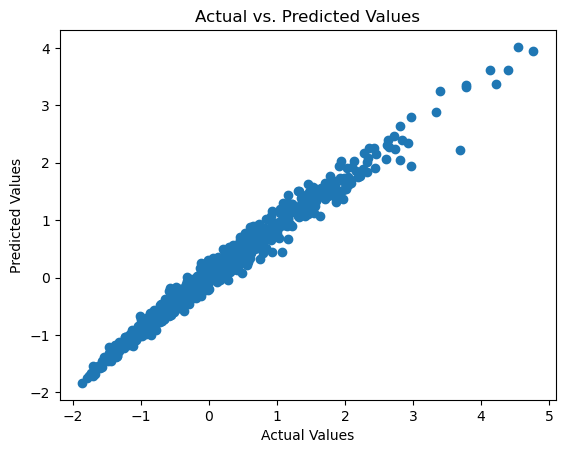

```python
import pandas as pd
from sklearn.preprocessing import StandardScaler
from sklearn.model_selection import train_test_split
from sklearn.linear_model import ElasticNet
from sklearn.metrics import r2_score, mean_squared_error
from math import sqrt
import matplotlib.pyplot as plt


# Load the data
female_data = pd.read_csv("nhanes_adult_female_bmx_2020 2(in).csv")

# Convert to DataFrame
female_data_df = pd.DataFrame(female_data)

# Calculate BMIs
female_bmi = female_data_df['BMXWT'] / (female_data_df['BMXHT'] ** 2)
female_data['FEMALEBMI'] = female_bmi

# Select only the numeric columns
numeric_cols = female_data.select_dtypes(include=['int64', 'float64']).columns

# Standardize only the numeric columns
scaler = StandardScaler()
zfemale = scaler.fit_transform(female_data[numeric_cols])

# Convert the standardized data to a DataFrame
zfemale_df = pd.DataFrame(zfemale, columns=numeric_cols)

# Split data and target
X = zfemale_df.drop('FEMALEBMI', axis=1)
y = zfemale_df['FEMALEBMI']

# Split data into training and testing sets
X_train, X_test, y_train, y_test = train_test_split(X, y, test_size=0.2, random_state=42)

# Create an ElasticNet regression model
model = ElasticNet(alpha=0.1)

# Train the model on the training data
model.fit(X_train, y_train)

# Make predictions on the testing data
y_pred = model.predict(X_test)

# Evaluate the model's performance
print("Mean squared error:", mean_squared_error(y_test, y_pred))
print("R-squared:", r2_score(y_test, y_pred))

# Create a scatter plot of actual values vs. predicted values
plt.scatter(y_test, y_pred)

# Add labels and title
plt.xlabel('Actual Values')
plt.ylabel('Predicted Values')
plt.title('Actual vs. Predicted Values')

# Display the plot
plt.show()
```

## 3) Lasso Regression

```
Mean squared error: 0.05467325773511648
R-squared: 0.9511484648760911
```

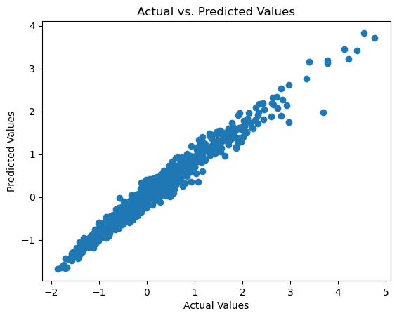

```python
from sklearn.linear_model import Lasso
from sklearn.metrics import r2_score, mean_squared_error
import matplotlib.pyplot as plt

# Create a Lasso regression model
model = Lasso(alpha=0.1)

# Train the model on the training data
model.fit(X_train, y_train)

# Make predictions on the testing data
y_pred = model.predict(X_test)

# Evaluate the model's performance
print("Mean squared error:", mean_squared_error(y_test, y_pred))
print("R-squared:", r2_score(y_test, y_pred))

# Create a scatter plot of actual values vs. predicted values
plt.scatter(y_test, y_pred)
plt.xlabel('Actual Values')
plt.ylabel('Predicted Values')
plt.title('Actual vs. Predicted Values')
plt.show()
```

## 4) Ridge Regression

```
Mean squared error: 0.007018481926607664
R-squared: 0.9937288606796523
```

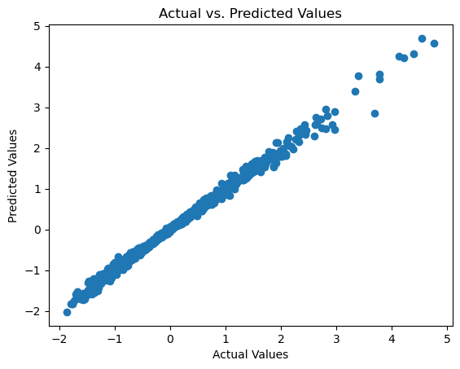

```python
from sklearn.linear_model import Ridge
from sklearn.metrics import r2_score, mean_squared_error
import matplotlib.pyplot as plt

# Create a Ridge regression model
model = Ridge(alpha=0.1)

# Train the model on the training data
model.fit(X_train, y_train)

# Make predictions on the testing data
y_pred = model.predict(X_test)

# Evaluate the model's performance
print("Mean squared error:", mean_squared_error(y_test, y_pred))
print("R-squared:", r2_score(y_test, y_pred))

# Create a scatter plot of actual values vs. predicted values
plt.scatter(y_test, y_pred)
plt.xlabel('Actual Values')
plt.ylabel('Predicted Values')
plt.title('Actual vs. Predicted Values')
plt.show()
```

### (Models') Performance

**-)** Our models are doing well, but might `not be capturing all patterns.`

**-)** Let's try converting **our data to polynomial features** to see if I can improve our models' performance!

### (Polynomial) Features

**-->** I'll use a special technique to transform **our data into polynomial features**.

**-->** This might help our models capture more complex patterns.

**-->** This can lead to better predictions and a more accurate model!

## 5.2. Polynomial Regression

**-->** Take our data and convert it into a polynomial format (like a special kind of math equation)

**-->** Use a tool called PolynomialFeatures from Scikit-Learn to do this.

**-->** Then, use this polynomial data to train and test your model.

### (Converting) our models to (Polynomial) Regression

**-->** Take our existing models (like LinearRegression, LassoRegression, RidgeRegression, ElasticNet Regression)

**-->** Use the PolynomialFeatures tool to convert your data into polynomial format.

**-->** Then, use this polynomial data to train and test your models.

Now, I taking **our existing models** and **"upgrading"** them to **work with polynomial data**, which can help our models make better predictions!

```python
import pandas as pd
from sklearn.preprocessing import PolynomialFeatures
from sklearn.linear_model import LinearRegression
from sklearn.model_selection import train_test_split
import pandas as pd

female_data = pd.read_csv("nhanes_adult_female_bmx_2020 2(in).csv")

# Convert to DataFrame
female_data_df = pd.DataFrame(female_data)

# Calculate BMIs
female_bmi = female_data_df['BMXWT'] / (female_data_df['BMXHT'] ** 2)
female_data['FEMALEBMI'] = female_bmi

# Select only the numeric columns
numeric_cols = female_data.select_dtypes(include=['int64', 'float64']).columns

# Standardize only the numeric columns
scaler = StandardScaler()
zfemale = scaler.fit_transform(female_data[numeric_cols])

# Convert the standardized data to a DataFrame
zfemale_df = pd.DataFrame(zfemale, columns=numeric_cols)

# Split data and target
X = zfemale_df.drop('FEMALEBMI', axis=1)
y = zfemale_df['FEMALEBMI']


# Select the features and target variable
X = female_data.drop(['FEMALEBMI'], axis=1)
y = female_data['FEMALEBMI']

# Split the data into training and testing sets
X_train, X_test, y_train, y_test = train_test_split(X, y, test_size=0.2, random_state=42)

# Create a PolynomialFeatures instance with degree 3
polynomial_features = PolynomialFeatures(degree=3)

# Fit and transform the training data to polynomial
X_train_poly = polynomial_features.fit_transform(X_train)

# Fit and transform the testing data to polynomial
X_test_poly = polynomial_features.transform(X_test)

# Create a LinearRegression model
polynomial_reg = LinearRegression(fit_intercept=False)

# Fit the model to the polynomial training data
polynomial_reg.fit(X_train_poly, y_train)

# Make predictions on the polynomial testing data
y_pred = polynomial_reg.predict(X_test_poly)

# Evaluate the model's performance
print("Mean squared error:", mean_squared_error(y_test, y_pred))
print("R-squared:", r2_score(y_test, y_pred))
```

```
Mean squared error: 5.385868448455623e-13
R-squared: 0.9999991994593451
```

### (PolynomialFeatures)

**-->** R-squared: 0.9999992 (virtually perfect! The model explains 99.99992% of the data)

1)Here's an insight into the Polynomial Features.

How well does the model fit the data?

**-->R-squared**: 0.9999992 (almost perfect!)

**-->** The model explains 99.99992% of the data, which is extremely good!

How accurate are the predictions?

**-->** The model's predictions are very close to the actual values, with only a tiny error.

```
Mean squared error: 5.385868448455623e-13
R-squared: 0.9999991994593451
```

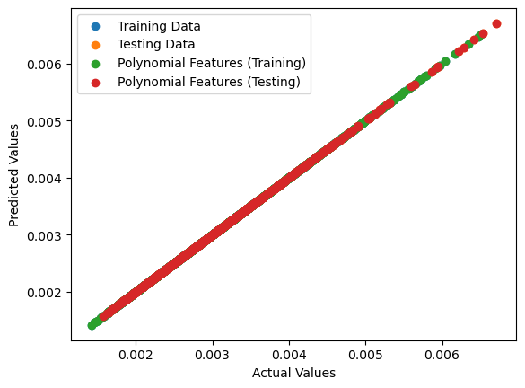

```python
import matplotlib.pyplot as plt

import pandas as pd
from sklearn.preprocessing import PolynomialFeatures
from sklearn.linear_model import LinearRegression
from sklearn.model_selection import train_test_split
import pandas as pd

female_data = pd.read_csv("nhanes_adult_female_bmx_2020 2(in).csv")

# Convert to DataFrame
female_data_df = pd.DataFrame(female_data)

# Calculate BMIs
female_bmi = female_data_df['BMXWT'] / (female_data_df['BMXHT'] ** 2)
female_data['FEMALEBMI'] = female_bmi

# Select only the numeric columns
numeric_cols = female_data.select_dtypes(include=['int64', 'float64']).columns

# Standardize only the numeric columns
scaler = StandardScaler()
zfemale = scaler.fit_transform(female_data[numeric_cols])

# Convert the standardized data to a DataFrame
zfemale_df = pd.DataFrame(zfemale, columns=numeric_cols)

# Split data and target
X = zfemale_df.drop('FEMALEBMI', axis=1)
y = zfemale_df['FEMALEBMI']


# Select the features and target variable
X = female_data.drop(['FEMALEBMI'], axis=1)
y = female_data['FEMALEBMI']

# Split the data into training and testing sets
X_train, X_test, y_train, y_test = train_test_split(X, y, test_size=0.2, random_state=42)

# Create a PolynomialFeatures instance with degree 3
polynomial_features = PolynomialFeatures(degree=3)

# Fit and transform the training data to polynomial
X_train_poly = polynomial_features.fit_transform(X_train)

# Fit and transform the testing data to polynomial
X_test_poly = polynomial_features.transform(X_test)

# Create a LinearRegression model
polynomial_reg = LinearRegression(fit_intercept=False)

# Fit the model to the polynomial training data
polynomial_reg.fit(X_train_poly, y_train)

# Make predictions on the polynomial testing data
y_pred = polynomial_reg.predict(X_test_poly)

# Evaluate the model's performance
print("Mean squared error:", mean_squared_error(y_test, y_pred))
print("R-squared:", r2_score(y_test, y_pred))

# Prediction with training dataset:
y_pred_MLR_train = polynomial_reg.predict(X_train_poly)

# Prediction with testing dataset:
y_pred_MLR_test = polynomial_reg.predict(X_test_poly)



plt.scatter(y_train, y_pred_MLR_train, label='Training Data')
plt.scatter(y_test, y_pred_MLR_test, label='Testing Data')
plt.scatter(y_train, polynomial_reg.predict(X_train_poly), label='Polynomial Features (Training)')
plt.scatter(y_test, polynomial_reg.predict(X_test_poly), label='Polynomial Features (Testing)')
plt.xlabel('Actual Values')
plt.ylabel('Predicted Values')
plt.legend()
plt.show()
```

Polynomial Features Magic!

**-->** I converted our data to polynomial features and now, our models **fit** the data ALMOST PERFECTLY!

## Visualize our models

**-->** Take our existing models `(like LinearRegression, LassoRegression, RidgeRegression, ElasticNet Regression)`

**-->** Use a graph to show how well each model is performing.

**-->** This will help you compare and see which model is doing the best job at predicting the data.

## 1) LinearRegression

```
Linear Regression - Mean squared error: 8.959425247467046e-07
Linear Regression - R-squared: 0.9999991994593055
```

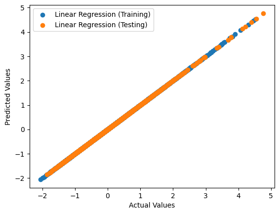

```python
import matplotlib.pyplot as plt
import pandas as pd
from sklearn.preprocessing import PolynomialFeatures
from sklearn.linear_model import LinearRegression, Ridge, Lasso
from sklearn.model_selection import train_test_split
from sklearn.metrics import mean_squared_error, r2_score
from sklearn.preprocessing import StandardScaler

# Load data
female_data = pd.read_csv("nhanes_adult_female_bmx_2020 2(in).csv")

# Calculate BMIs
female_bmi = female_data['BMXWT'] / (female_data['BMXHT'] ** 2)
female_data['FEMALEBMI'] = female_bmi

# Select only the numeric columns
numeric_cols = female_data.select_dtypes(include=['int64', 'float64']).columns

# Standardize only the numeric columns
scaler = StandardScaler()
zfemale = scaler.fit_transform(female_data[numeric_cols])
zfemale_df = pd.DataFrame(zfemale, columns=numeric_cols)

# Split data and target
X = zfemale_df.drop('FEMALEBMI', axis=1)
y = zfemale_df['FEMALEBMI']

# Split the data into training and testing sets
X_train, X_test, y_train, y_test = train_test_split(X, y, test_size=0.2, random_state=42)

# Create a PolynomialFeatures instance with degree 3
polynomial_features = PolynomialFeatures(degree=3)

# Fit and transform the training data to polynomial
X_train_poly = polynomial_features.fit_transform(X_train)
X_test_poly = polynomial_features.transform(X_test)


# Prediction with training dataset:
y_pred_MLR_train = polynomial_reg.predict(X_train_poly)

# Prediction with testing dataset:
y_pred_MLR_test = polynomial_reg.predict(X_test_poly)

# Linear Regression
linear_reg = LinearRegression(fit_intercept=False)
linear_reg.fit(X_train_poly, y_train)
y_pred_linear = linear_reg.predict(X_test_poly)
print("Linear Regression - Mean squared error:", mean_squared_error(y_test, y_pred_linear))
print("Linear Regression - R-squared:", r2_score(y_test, y_pred_linear))


# Scatter plots
plt.scatter(y_train, linear_reg.predict(X_train_poly), label='Linear Regression (Training)')
plt.scatter(y_test, y_pred_linear, label='Linear Regression (Testing)')
plt.xlabel('Actual Values')
plt.ylabel('Predicted Values')
plt.legend()
plt.show()
```

## 2) RidgeRegression

```
Ridge Regression - Mean squared error: 9.871379221724152e-07
Ridge Regression - R-squared: 0.9999991179745844
```

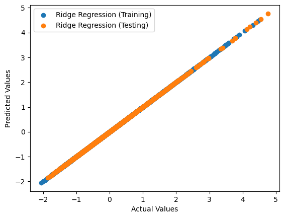

```python
import matplotlib.pyplot as plt
import pandas as pd
from sklearn.preprocessing import PolynomialFeatures
from sklearn.linear_model import LinearRegression, Ridge, Lasso
from sklearn.model_selection import train_test_split
from sklearn.metrics import mean_squared_error, r2_score
from sklearn.preprocessing import StandardScaler

# Load data
female_data = pd.read_csv("nhanes_adult_female_bmx_2020 2(in).csv")

# Calculate BMIs
female_bmi = female_data['BMXWT'] / (female_data['BMXHT'] ** 2)
female_data['FEMALEBMI'] = female_bmi

# Select only the numeric columns
numeric_cols = female_data.select_dtypes(include=['int64', 'float64']).columns

# Standardize only the numeric columns
scaler = StandardScaler()
zfemale = scaler.fit_transform(female_data[numeric_cols])
zfemale_df = pd.DataFrame(zfemale, columns=numeric_cols)

# Split data and target
X = zfemale_df.drop('FEMALEBMI', axis=1)
y = zfemale_df['FEMALEBMI']

# Split the data into training and testing sets
X_train, X_test, y_train, y_test = train_test_split(X, y, test_size=0.2, random_state=42)

# Create a PolynomialFeatures instance with degree 3
polynomial_features = PolynomialFeatures(degree=3)

# Fit and transform the training data to polynomial
X_train_poly = polynomial_features.fit_transform(X_train)
X_test_poly = polynomial_features.transform(X_test)


# Prediction with training dataset:
y_pred_MLR_train = polynomial_reg.predict(X_train_poly)

# Prediction with testing dataset:
y_pred_MLR_test = polynomial_reg.predict(X_test_poly)


# Ridge Regression
ridge_reg = Ridge(alpha=0.1, fit_intercept=False)
ridge_reg.fit(X_train_poly, y_train)
y_pred_ridge = ridge_reg.predict(X_test_poly)

print("Ridge Regression - Mean squared error:", mean_squared_error(y_test, y_pred_ridge))
print("Ridge Regression - R-squared:", r2_score(y_test, y_pred_ridge))

# Scatter plots
plt.scatter(y_train, ridge_reg.predict(X_train_poly), label='Ridge Regression (Training)')
plt.scatter(y_test, y_pred_ridge, label='Ridge Regression (Testing)')
plt.xlabel('Actual Values')
plt.ylabel('Predicted Values')
plt.legend()
plt.show()
```

## 3) LassoRegression

```
Lasso Regression - Mean squared error: 0.06227892003068855
Lasso Regression - R-squared: 0.9443526693781747
```

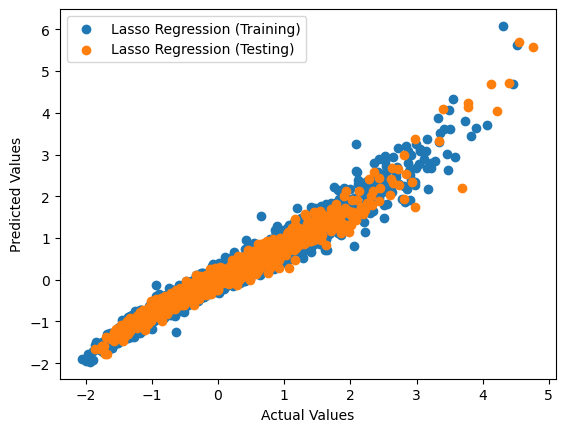

```python
import matplotlib.pyplot as plt
import pandas as pd
from sklearn.preprocessing import PolynomialFeatures
from sklearn.linear_model import LinearRegression, Ridge, Lasso
from sklearn.model_selection import train_test_split
from sklearn.metrics import mean_squared_error, r2_score
from sklearn.preprocessing import StandardScaler

# Load data
female_data = pd.read_csv("nhanes_adult_female_bmx_2020 2(in).csv")

# Calculate BMIs
female_bmi = female_data['BMXWT'] / (female_data['BMXHT'] ** 2)
female_data['FEMALEBMI'] = female_bmi

# Select only the numeric columns
numeric_cols = female_data.select_dtypes(include=['int64', 'float64']).columns

# Standardize only the numeric columns
scaler = StandardScaler()
zfemale = scaler.fit_transform(female_data[numeric_cols])
zfemale_df = pd.DataFrame(zfemale, columns=numeric_cols)

# Split data and target
X = zfemale_df.drop('FEMALEBMI', axis=1)
y = zfemale_df['FEMALEBMI']

# Split the data into training and testing sets
X_train, X_test, y_train, y_test = train_test_split(X, y, test_size=0.2, random_state=42)

# Create a PolynomialFeatures instance with degree 3
polynomial_features = PolynomialFeatures(degree=3)

# Fit and transform the training data to polynomial
X_train_poly = polynomial_features.fit_transform(X_train)
X_test_poly = polynomial_features.transform(X_test)

# Lasso Regression
lasso_reg = Lasso(alpha=0.1, fit_intercept=False)
lasso_reg.fit(X_train_poly, y_train)

# Prediction with training dataset
y_pred_MLR_train = lasso_reg.predict(X_train_poly)

# Prediction with testing dataset
y_pred_MLR_test = lasso_reg.predict(X_test_poly)

print("Lasso Regression - Mean squared error:", mean_squared_error(y_test, y_pred_MLR_test))
print("Lasso Regression - R-squared:", r2_score(y_test, y_pred_MLR_test))

# Scatter plots
plt.scatter(y_train, lasso_reg.predict(X_train_poly), label='Lasso Regression (Training)')
plt.scatter(y_test, y_pred_MLR_test, label='Lasso Regression (Testing)')
plt.xlabel('Actual Values')
plt.ylabel('Predicted Values')
plt.legend()
plt.show()
```

## 4) ElasticNet Regression

```
ElasticNet Regression - Mean squared error: 0.03541939554176439
ElasticNet Regression - R-squared: 0.9683521356316626
```

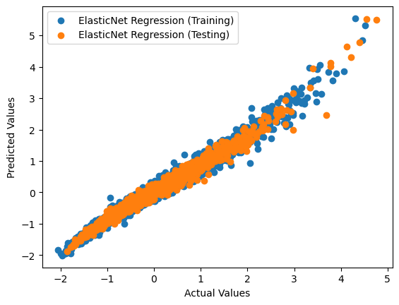

```python
import matplotlib.pyplot as plt
import pandas as pd
from sklearn.preprocessing import PolynomialFeatures
from sklearn.linear_model import ElasticNet
from sklearn.model_selection import train_test_split
from sklearn.metrics import mean_squared_error, r2_score
from sklearn.preprocessing import StandardScaler

# Load data
female_data = pd.read_csv("nhanes_adult_female_bmx_2020 2(in).csv")

# Calculate BMIs
female_bmi = female_data['BMXWT'] / (female_data['BMXHT'] ** 2)
female_data['FEMALEBMI'] = female_bmi

# Select only the numeric columns
numeric_cols = female_data.select_dtypes(include=['int64', 'float64']).columns

# Standardize only the numeric columns
scaler = StandardScaler()
zfemale = scaler.fit_transform(female_data[numeric_cols])
zfemale_df = pd.DataFrame(zfemale, columns=numeric_cols)

# Split data and target
X = zfemale_df.drop('FEMALEBMI', axis=1)
y = zfemale_df['FEMALEBMI']

# Split the data into training and testing sets
X_train, X_test, y_train, y_test = train_test_split(X, y, test_size=0.2, random_state=42)

# Create a PolynomialFeatures instance with degree 3
polynomial_features = PolynomialFeatures(degree=3)

# Fit and transform the training data to polynomial
X_train_poly = polynomial_features.fit_transform(X_train)
X_test_poly = polynomial_features.transform(X_test)

# ElasticNet Regression
elastic_net_reg = ElasticNet(alpha=0.1, fit_intercept=False)
elastic_net_reg.fit(X_train_poly, y_train)
y_pred_elastic_net = elastic_net_reg.predict(X_test_poly)

print("ElasticNet Regression - Mean squared error:", mean_squared_error(y_test, y_pred_elastic_net))
print("ElasticNet Regression - R-squared:", r2_score(y_test, y_pred_elastic_net))

# Scatter plots
plt.scatter(y_train, elastic_net_reg.predict(X_train_poly), label='ElasticNet Regression (Training)')
plt.scatter(y_test, y_pred_elastic_net, label='ElasticNet Regression (Testing)')
plt.xlabel('Actual Values')
plt.ylabel('Predicted Values')
plt.legend()
plt.show()
```

## 5.3. Model Selection

**-->** I tried multiple models, but only **two** are a perfect fit:

**-->** Linear Regression

**-->** Ridge Regression

Why these two?

**-->** They both have an extremely **high R-squared value** (almost 1!), meaning they capture the patterns in the data very well.

**-->** They are both simple and easy to interpret, making them great choices for our problem.

**-->** **(Linear)** Regression:

**-->** It's a simple and classic model that works well when the relationship is linear.

**-->** **(Ridge)** Regression:

**-->** It's similar to Linear Regression but adds a tiny bit of regularization to prevent overfitting.

Next, I can use either **Linear Regression or Ridge Regression for our problem, as both are a great fit!**. I can also consider other  
**factors like model complexity and interpretability to make our final choice**.

## 6. EVALUATING MODELS

In this section I will do **some measurements to evaluate the performance on these two models** I fit. In addition, **10-Fold Cross Validation** method will perform the validation process. **R Squared Score** method will be used for calculating the accuracy of the models. **Mean Squared Error (MSE)** method will be used for error measurement. As the MSE result can be very large, its **square root will be taken and converted into RMSE**. **The error and accuracy calculation shall be performed on both the test and training dataset**. **Let's first perform evaluation for these two model by importing the necessary functions**:

```python
import pandas as pd
from sklearn.preprocessing import PolynomialFeatures
from sklearn.linear_model import LinearRegression, Ridge
from sklearn.preprocessing import StandardScaler
from sklearn.model_selection import train_test_split, cross_val_predict
from sklearn.metrics import r2_score, mean_squared_error
from math import sqrt

# Load the data
female_data = pd.read_csv("nhanes_adult_female_bmx_2020 2(in).csv")

# Convert to DataFrame
female_data_df = pd.DataFrame(female_data)

# Calculate BMIs
female_bmi = female_data_df['BMXWT'] / (female_data_df['BMXHT'] ** 2)
female_data['FEMALEBMI'] = female_bmi

# Select only the numeric columns
numeric_cols = female_data.select_dtypes(include=['int64', 'float64']).columns

# Standardize only the numeric columns
scaler = StandardScaler()
zfemale = scaler.fit_transform(female_data[numeric_cols])

# Convert the standardized data to a DataFrame
zfemale_df = pd.DataFrame(zfemale, columns=numeric_cols)

# Split data and target
X = zfemale_df.drop('FEMALEBMI', axis=1)
y = zfemale_df['FEMALEBMI']

# Split the data into training and testing sets
X_train, X_test, y_train, y_test = train_test_split(X, y, test_size=0.2, random_state=42)

# Create a PolynomialFeatures instance with degree 3
polynomial_features = PolynomialFeatures(degree=3)

# Fit and transform the training data to polynomial
X_train_poly = polynomial_features.fit_transform(X_train)

# Fit and transform the testing data to polynomial
X_test_poly = polynomial_features.transform(X_test)

# Create a Linear Regression model
linear_reg = LinearRegression(fit_intercept=False)

# Fit the model to the polynomial training data
linear_reg.fit(X_train_poly, y_train)

# Prediction with training dataset:
y_pred_LR_train = linear_reg.predict(X_train_poly)

# Prediction with testing dataset:
y_pred_LR_test = linear_reg.predict(X_test_poly)

# Find training accuracy for this model:
accuracy_LR_train = r2_score(y_train, y_pred_LR_train)
print("Training Accuracy for Linear Regression Model: ", accuracy_LR_train)

# Find testing accuracy for this model:
accuracy_LR_test = r2_score(y_test, y_pred_LR_test)
print("Testing Accuracy for Linear Regression Model: ", accuracy_LR_test)

# Find RMSE for training data:
RMSE_LR_train = sqrt(mean_squared_error(y_train, y_pred_LR_train))
print("RMSE for Training Data: ", RMSE_LR_train)

# Find RMSE for testing data:
RMSE_LR_test = sqrt(mean_squared_error(y_test, y_pred_LR_test))
print("RMSE for Testing Data: ", RMSE_LR_test)

# Prediction with 10-Fold Cross Validation:
y_pred_cv_LR = cross_val_predict(linear_reg, X, y, cv=10)

# Find accuracy after 10-Fold Cross Validation
accuracy_cv_LR = r2_score(y, y_pred_cv_LR)
print("Accuracy for 10-Fold Cross Predicted Linear Regression Model: ", accuracy_cv_LR)

# Create a Ridge regression model
ridge_reg = Ridge(alpha=0.1, fit_intercept=False)

# Fit the model to the polynomial training data
ridge_reg.fit(X_train_poly, y_train)

# Prediction with training dataset:
y_pred_RR_train = ridge_reg.predict(X_train_poly)

# Prediction with testing dataset:
y_pred_RR_test = ridge_reg.predict(X_test_poly)

# Find training accuracy for this model:
accuracy_RR_train = r2_score(y_train, y_pred_RR_train)
print("Training Accuracy for Ridge Regression Model: ", accuracy_RR_train)

# Find testing accuracy for this model:
accuracy_RR_test = r2_score(y_test, y_pred_RR_test)
print("Testing Accuracy for Ridge Regression Model: ", accuracy_RR_test)

# Find RMSE for training data:
RMSE_RR_train = sqrt(mean_squared_error(y_train, y_pred_RR_train))
print("RMSE for Training Data: ", RMSE_RR_train)

# Find RMSE for testing data:
RMSE_RR_test = sqrt(mean_squared_error(y_test, y_pred_RR_test))
print("RMSE for Testing Data: ", RMSE_RR_test)

# Prediction with 10-Fold Cross Validation:
y_pred_cv_RR = cross_val_predict(ridge_reg, X, y, cv=10)

# Find accuracy after 10-Fold Cross Validation
accuracy_cv_RR = r2_score(y, y_pred_cv_RR)
print("Accuracy for 10-Fold Cross Predicted Ridge Regression Model: ", accuracy_cv_RR)
```

```
Training Accuracy for Linear Regression Model:  0.9999995451133104
Testing Accuracy for Linear Regression Model:  0.9999991994593055
RMSE for Training Data:  0.0006639600651235769
RMSE for Testing Data:  0.0009465424051497665
Accuracy for 10-Fold Cross Predicted Linear Regression Model:  0.993620542410539
Training Accuracy for Ridge Regression Model:  0.9999994074822737
Testing Accuracy for Ridge Regression Model:  0.9999991179745844
RMSE for Training Data:  0.0007577762997147554
RMSE for Testing Data:  0.0009935481478883725
Accuracy for 10-Fold Cross Predicted Ridge Regression Model:  0.9936205707358843
```

## Comparison:

**Linear Regression (LR)** vs. **Ridge Regression (RR)**

**Similarities**:

**-->** Both models have extremely high accuracy (above 99.99%) and very low error rates (RMSE).

**-->** Both models perform well in 10-fold cross-validation (accuracy: 99.36%).

**Differences**:

**-->** **Linear Regression** has slightly **better accuracy** and **lower RMSE values** than **Ridge Regression**.

**-->** **Ridge Regression** has a slightly **higher accuracy** in **10-fold cross-validation**, but the difference is negligible.

**Conclusion**:

**-->** Both models fit the data extremely well, but **Linear Regression** is the **best fit**, followed closely by `Ridge Regression.`

In simple terms, both models are excellent choices, but Linear Regression has a slight edge.

## 7. EXPLORATION OF RESULTS

In general, let's put all the results of the models into the table:

```python
import pandas as pd
from sklearn.preprocessing import PolynomialFeatures
from sklearn.linear_model import LinearRegression, Ridge
from sklearn.preprocessing import StandardScaler
from sklearn.model_selection import train_test_split, cross_val_predict
from sklearn.metrics import r2_score, mean_squared_error
from math import sqrt

# Load the data
female_data = pd.read_csv("nhanes_adult_female_bmx_2020 2(in).csv")

# Convert to DataFrame
female_data_df = pd.DataFrame(female_data)

# Calculate BMIs
female_bmi = female_data_df['BMXWT'] / (female_data_df['BMXHT'] ** 2)
female_data['FEMALEBMI'] = female_bmi

# Select only the numeric columns
numeric_cols = female_data.select_dtypes(include=['int64', 'float64']).columns

# Standardize only the numeric columns
scaler = StandardScaler()
zfemale = scaler.fit_transform(female_data[numeric_cols])

# Convert the standardized data to a DataFrame
zfemale_df = pd.DataFrame(zfemale, columns=numeric_cols)

# Split data and target
X = zfemale_df.drop('FEMALEBMI', axis=1)
y = zfemale_df['FEMALEBMI']

# Split the data into training and testing sets
X_train, X_test, y_train, y_test = train_test_split(X, y, test_size=0.2, random_state=42)

# Create a PolynomialFeatures instance with degree 3
polynomial_features = PolynomialFeatures(degree=3)

# Fit and transform the training data to polynomial
X_train_poly = polynomial_features.fit_transform(X_train)

# Fit and transform the testing data to polynomial
X_test_poly = polynomial_features.transform(X_test)

# Create a Linear Regression model
linear_reg = LinearRegression(fit_intercept=False)

# Fit the model to the polynomial training data
linear_reg.fit(X_train_poly, y_train)

# Prediction with training dataset:
y_pred_LR_train = linear_reg.predict(X_train_poly)

# Prediction with testing dataset:
y_pred_LR_test = linear_reg.predict(X_test_poly)

# Find training accuracy for this model:
accuracy_LR_train = r2_score(y_train, y_pred_LR_train)

# Find testing accuracy for this model:
accuracy_LR_test = r2_score(y_test, y_pred_LR_test)

# Find RMSE for training data:
RMSE_LR_train = sqrt(mean_squared_error(y_train, y_pred_LR_train))

# Find RMSE for testing data:
RMSE_LR_test = sqrt(mean_squared_error(y_test, y_pred_LR_test))

# Prediction with 10-Fold Cross Validation:
y_pred_cv_LR = cross_val_predict(linear_reg, X, y, cv=10)

# Find accuracy after 10-Fold Cross Validation
accuracy_cv_LR = r2_score(y, y_pred_cv_LR)

# Create a Ridge regression model
ridge_reg = Ridge(alpha=0.1, fit_intercept=False)

# Fit the model to the polynomial training data
ridge_reg.fit(X_train_poly, y_train)

# Prediction with training dataset:
y_pred_RR_train = ridge_reg.predict(X_train_poly)

# Prediction with testing dataset:
y_pred_RR_test = ridge_reg.predict(X_test_poly)

# Find training accuracy for this model:
accuracy_RR_train = r2_score(y_train, y_pred_RR_train)

# Find testing accuracy for this model:
accuracy_RR_test = r2_score(y_test, y_pred_RR_test)

# Find RMSE for training data:
RMSE_RR_train = sqrt(mean_squared_error(y_train, y_pred_RR_train))

# Find RMSE for testing data:
RMSE_RR_test = sqrt(mean_squared_error(y_test, y_pred_RR_test))

# Prediction with 10-Fold Cross Validation:
y_pred_cv_RR = cross_val_predict(ridge_reg, X, y, cv=10)

# Find accuracy after 10-Fold Cross Validation
accuracy_cv_RR = r2_score(y, y_pred_cv_RR)

# Put all the results of the models into the table
training_accuracies = [accuracy_LR_train, accuracy_RR_train]
testing_accuracies = [accuracy_LR_test, accuracy_RR_test]
training_RMSE = [RMSE_LR_train, RMSE_RR_train]
testing_RMSE = [RMSE_LR_test, RMSE_RR_test]
cv_accuracies = [accuracy_cv_LR, accuracy_cv_RR]

table_data = {"Training Accuracy": training_accuracies, "Testing Accuracy": testing_accuracies,
              "Training RMSE": training_RMSE, "Testing RMSE": testing_RMSE, "10-Fold Score": cv_accuracies}
model_names = ["Linear Regression", "Ridge Regression"]
table_dataframe = pd.DataFrame(data=table_data, index=model_names)
print(table_dataframe)
```

```
                   Training Accuracy  Testing Accuracy  Training RMSE  \
Linear Regression           1.000000          0.999999       0.000664
Ridge Regression            0.999999          0.999999       0.000758

                   Testing RMSE  10-Fold Score
Linear Regression      0.000947       0.993621
Ridge Regression       0.000994       0.993621
```

## INTERPERT THE RESULT:

I used **two machine learning models (Linear Regression and Ridge Regression)** `to predict BMI (Body Mass Index)` from a dataset of female health metrics.

I evaluated their performance using various metrics:

**-->** **Training Accuracy**: How well the model fits the training data.

**-->** **Testing Accuracy**: How well the model generalizes to new data.

**-->** **Training RMSE (Root Mean Squared Error)**: The average distance between predicted and actual values in the training data.

**-->** **Testing RMSE**: The average distance between predicted and actual values in the testing data.

**-->** **10-Fold Score**: The average accuracy of the model when trained and tested on 10 different subsets of the data.

The results show that **both models perform very well**, **with high accuracy and low RMSE values**.

**-->** The `Linear Regression model` **has a slightly better performance than the** `Ridge Regression model.`

## 8. CONCLUSION

This kernel is designed to completely illustrate regression and EDA stages in machine learning. You can use the code and information in the example as desired.

**--> Data Science processes**

**--> How a Dataset Exploratory Data Analysis (EDA) is made**

**--> Find and visualize the correlation between features in data**

**--> How to make various visualizations about dataset**

**--> Use of libraries such as Pandas, Matplotlib, Seaborn and Scikit-Learn in Python**

**--> How to do Data Cleaning simply**

**--> How to split Dataset into Test and Train**

**--> How to install and learn Machine Learning models**

**--> How polynomial is made in Polynomial Regression**

**--> How to do the Evaluating on the installed models**

**--> How the R-Squared Score is located**

**--> How RMSE values are located**

**--> How K-Fold Cross Validation is done and how the score is calculated**

**--> How the models evaluated are visually compared and interpreted**